# Δ AUC under different models: type 2 diabetes, European-trained scores

## What this page is for

- The main analysis estimates Δ AUC, the AUC of a score in another ancestry group minus its AUC in European participants, with two inverse-variance (IVW) averages.
- On this page I ask one question about one example: **which model should the analysis use?**
- I use type 2 diabetes as the example, with scores trained only on European data, South Asian versus European.
- A second, shorter example is Hispanic or Latin American versus European.
- Hispanic or Latin American in type 2 diabetes is an example of 18 of the 32 comparisons in the analysis, where every score uses one European and one target sample set. These comparisons are spread across all 12 traits.
- South Asian is an example of the 9 comparisons with more than one score and more than one sample set. They come from two traits: 7 within type 2 diabetes and 2 within breast cancer.

Every route starts from the same master table and ends on the AUC scale, so I can put the answers side by side:

| Pipeline | Scale of the model | Model | Back to AUC |
| --- | --- | --- | --- |
| 1 | logit, then AUC | IVW within each score and ancestry (stage 1), then IVW of the per-score differences (stage 2) | after stage 1 |
| 2 | logit | `lm`, then `lmer`, adding terms one at a time | after the model |
| 3 | AUC | the same `lm` and `lmer` models | not needed |
| 4 | logit | `rma.mv` from metafor | after the model |
| 5 | AUC | the same `rma.mv` models | not needed |

I show the model calls. The rest of the code is behind the **Code** buttons.

**Where to look first.**

- Open questions: the five points I would like input on.
- All South Asian estimates side by side and all Hispanic or Latin American estimates side by side: one table and one plot per comparison, with every model on this page.
- Pipeline 1 gives almost the same estimate and SE as the `rma.mv` model on the AUC scale with ancestry and score as fixed terms and no random effects (model 5.2: South Asian, Hispanic or Latin American).

# South Asian versus European

## The master table

- Each row is one AUC reported in the PGS Catalog: one score, evaluated in one sample set (a PSS identifier, a fixed group of people), in one ancestry group.
- For each score I keep only the covariate class the main analysis uses, so that every model below sees the rows the analysis sees.

```r
kable(sa %>% select(-PGS, -cohort), digits = 4)
```

| pgs_id | ancestry | sampleset_id | study | n_individuals | covariate_class | auc | ci_lower | ci_upper | logit_auc | se_logit | se_auc |
| --- | --- | --- | --- | --- | --- | --- | --- | --- | --- | --- | --- |
| PGS000330 | European | PSS011737 | All of Us | 109021 | Age/sex/PCs/technical | 0.7260 | 0.7210 | 0.7300 | 0.9744 | 0.0115 | 0.0023 |
| PGS000713 | European | PSS011737 | All of Us | 109021 | Age/sex/PCs/technical | 0.7120 | 0.7070 | 0.7170 | 0.9051 | 0.0124 | 0.0026 |
| PGS000729 | European | PSS011737 | All of Us | 109021 | Age/sex/PCs/technical | 0.7120 | 0.7070 | 0.7170 | 0.9051 | 0.0124 | 0.0026 |
| PGS000805 | European | PSS011737 | All of Us | 109021 | Age/sex/PCs/technical | 0.7070 | 0.7020 | 0.7120 | 0.8809 | 0.0123 | 0.0026 |
| PGS000864 | European | PSS011737 | All of Us | 109021 | Age/sex/PCs/technical | 0.6870 | 0.6820 | 0.6920 | 0.7861 | 0.0119 | 0.0026 |
| PGS000868 | European | PSS011737 | All of Us | 109021 | Age/sex/PCs/technical | 0.6960 | 0.6910 | 0.7010 | 0.8283 | 0.0121 | 0.0026 |
| PGS001295 | European | PSS004314 | UK Biobank | 24905 | Age/sex/PCs/technical | 0.6932 | 0.6562 | 0.7301 | 0.8150 | 0.0889 | 0.0189 |
| PGS001295 | European | PSS004316 | UK Biobank | 67425 | Age/sex/PCs/technical | 0.6825 | 0.6616 | 0.7034 | 0.7651 | 0.0493 | 0.0107 |
| PGS001818 | European | PSS011737 | All of Us | 109021 | Age/sex/PCs/technical | 0.7090 | 0.7040 | 0.7140 | 0.8905 | 0.0124 | 0.0026 |
| PGS002026 | European | PSS011737 | All of Us | 109021 | Age/sex/PCs/technical | 0.7140 | 0.7090 | 0.7190 | 0.9149 | 0.0125 | 0.0026 |
| PGS002671 | European | PSS011737 | All of Us | 109021 | Age/sex/PCs/technical | 0.7040 | 0.6990 | 0.7080 | 0.8664 | 0.0110 | 0.0023 |
| PGS002771 | European | PSS011737 | All of Us | 109021 | Age/sex/PCs/technical | 0.7350 | 0.7300 | 0.7400 | 1.0201 | 0.0131 | 0.0026 |
| PGS002780 | European | PSS011737 | All of Us | 109021 | Age/sex/PCs/technical | 0.6940 | 0.6890 | 0.6990 | 0.8189 | 0.0120 | 0.0026 |
| PGS004106 | European | PSS011225 | EB | 199274 | None (PRS only) | 0.5640 | 0.5588 | 0.5692 | 0.2575 | 0.0108 | 0.0027 |
| PGS004106 | European | PSS011236 | FinnGen | 377408 | None (PRS only) | 0.5677 | 0.5652 | 0.5702 | 0.2723 | 0.0052 | 0.0013 |
| PGS004106 | European | PSS011265 | HUNT | 66865 | None (PRS only) | 0.5754 | 0.5661 | 0.5847 | 0.3038 | 0.0194 | 0.0047 |
| PGS004106 | European | PSS011278 | UK Biobank | 90274 | None (PRS only) | 0.5794 | 0.5719 | 0.5869 | 0.3203 | 0.0156 | 0.0038 |
| PGS000330 | South Asian | PSS011749 | UK Biobank | 6992 | Age/sex/PCs/technical | 0.7240 | 0.7090 | 0.7380 | 0.9644 | 0.0370 | 0.0074 |
| PGS000713 | South Asian | PSS011749 | UK Biobank | 6992 | Age/sex/PCs/technical | 0.7210 | 0.7050 | 0.7360 | 0.9494 | 0.0393 | 0.0079 |
| PGS000729 | South Asian | PSS011749 | UK Biobank | 6992 | Age/sex/PCs/technical | 0.7170 | 0.7030 | 0.7320 | 0.9296 | 0.0365 | 0.0074 |
| PGS000805 | South Asian | PSS011749 | UK Biobank | 6992 | Age/sex/PCs/technical | 0.7210 | 0.7060 | 0.7360 | 0.9494 | 0.0381 | 0.0077 |
| PGS000864 | South Asian | PSS011749 | UK Biobank | 6992 | Age/sex/PCs/technical | 0.6930 | 0.6780 | 0.7090 | 0.8142 | 0.0372 | 0.0079 |
| PGS000868 | South Asian | PSS011749 | UK Biobank | 6992 | Age/sex/PCs/technical | 0.7110 | 0.6960 | 0.7260 | 0.9002 | 0.0373 | 0.0077 |
| PGS001295 | South Asian | PSS004315 | UK Biobank | 7831 | Age/sex/PCs/technical | 0.6581 | 0.6186 | 0.6976 | 0.6547 | 0.0899 | 0.0202 |
| PGS001818 | South Asian | PSS011749 | UK Biobank | 6992 | Age/sex/PCs/technical | 0.7230 | 0.7080 | 0.7380 | 0.9594 | 0.0382 | 0.0077 |
| PGS002026 | South Asian | PSS011749 | UK Biobank | 6992 | Age/sex/PCs/technical | 0.7240 | 0.7090 | 0.7390 | 0.9644 | 0.0383 | 0.0077 |
| PGS002671 | South Asian | PSS011749 | UK Biobank | 6992 | Age/sex/PCs/technical | 0.7210 | 0.7060 | 0.7360 | 0.9494 | 0.0381 | 0.0077 |
| PGS002771 | South Asian | PSS011749 | UK Biobank | 6992 | Age/sex/PCs/technical | 0.7420 | 0.7280 | 0.7570 | 1.0564 | 0.0387 | 0.0074 |
| PGS002780 | South Asian | PSS011749 | UK Biobank | 6992 | Age/sex/PCs/technical | 0.7130 | 0.6980 | 0.7290 | 0.9100 | 0.0387 | 0.0079 |
| PGS004106 | South Asian | PSS011249 | Genes & Health | 44057 | None (PRS only) | 0.5471 | 0.5396 | 0.5546 | 0.1889 | 0.0154 | 0.0038 |
| PGS004106 | South Asian | PSS011291 | UK Biobank | 9326 | None (PRS only) | 0.5591 | 0.5450 | 0.5731 | 0.2374 | 0.0291 | 0.0072 |

- That is 31 rows: 13 scores in 11 sample sets.
- Every score has at least one European row and at least one South Asian row.
- The last three columns are the logit, its SE (from the catalog’s 95% CI), and that SE converted to the AUC scale. I explain where the logit comes in and goes out, and why, at the start of Pipeline 1.

### How are the rows spread over sample sets?

Before fitting anything, I wanted to see which scores were measured where.

```r
sa_layout <- sa %>%
  mutate(column = paste0(ancestry, " · ", sampleset_id, " (", study, ")")) %>%
  count(pgs_id, column) %>%
  pivot_wider(names_from = column, values_from = n, values_fill = 0)
kable(sa_layout)
```

| pgs_id | European · PSS011737 (All of Us) | South Asian · PSS011749 (UK Biobank) | European · PSS004314 (UK Biobank) | European · PSS004316 (UK Biobank) | South Asian · PSS004315 (UK Biobank) | European · PSS011225 (EB) | European · PSS011236 (FinnGen) | European · PSS011265 (HUNT) | European · PSS011278 (UK Biobank) | South Asian · PSS011249 (Genes & Health) | South Asian · PSS011291 (UK Biobank) |
| --- | --- | --- | --- | --- | --- | --- | --- | --- | --- | --- | --- |
| PGS000330 | 1 | 1 | 0 | 0 | 0 | 0 | 0 | 0 | 0 | 0 | 0 |
| PGS000713 | 1 | 1 | 0 | 0 | 0 | 0 | 0 | 0 | 0 | 0 | 0 |
| PGS000729 | 1 | 1 | 0 | 0 | 0 | 0 | 0 | 0 | 0 | 0 | 0 |
| PGS000805 | 1 | 1 | 0 | 0 | 0 | 0 | 0 | 0 | 0 | 0 | 0 |
| PGS000864 | 1 | 1 | 0 | 0 | 0 | 0 | 0 | 0 | 0 | 0 | 0 |
| PGS000868 | 1 | 1 | 0 | 0 | 0 | 0 | 0 | 0 | 0 | 0 | 0 |
| PGS001295 | 0 | 0 | 1 | 1 | 1 | 0 | 0 | 0 | 0 | 0 | 0 |
| PGS001818 | 1 | 1 | 0 | 0 | 0 | 0 | 0 | 0 | 0 | 0 | 0 |
| PGS002026 | 1 | 1 | 0 | 0 | 0 | 0 | 0 | 0 | 0 | 0 | 0 |
| PGS002671 | 1 | 1 | 0 | 0 | 0 | 0 | 0 | 0 | 0 | 0 | 0 |
| PGS002771 | 1 | 1 | 0 | 0 | 0 | 0 | 0 | 0 | 0 | 0 | 0 |
| PGS002780 | 1 | 1 | 0 | 0 | 0 | 0 | 0 | 0 | 0 | 0 | 0 |
| PGS004106 | 0 | 0 | 0 | 0 | 0 | 1 | 1 | 1 | 1 | 1 | 1 |

```r
sa_main_sets <- sa %>%
  count(ancestry, sampleset_id, study) %>%
  group_by(ancestry) %>%
  slice_max(n, n = 1, with_ties = FALSE) %>%
  ungroup()
sa_eur_main <- sa_main_sets$sampleset_id[sa_main_sets$ancestry == "European"]
sa_tgt_main <- sa_main_sets$sampleset_id[sa_main_sets$ancestry != "European"]
sa_n_tied <- sa %>%
  group_by(pgs_id) %>%
  summarise(tied = all(sampleset_id[ancestry == "European"] == sa_eur_main) &
    all(sampleset_id[ancestry != "European"] == sa_tgt_main)) %>%
  pull(tied) %>%
  sum()
```

- 11 of the 13 scores were measured in exactly one European sample set, PSS011737 (All of Us), and one South Asian sample set, PSS011749 (UK Biobank).
- So for most scores, it seems to me that comparing the two ancestry groups is also comparing two different studies.

## Pipeline 1: IVW in two stages (the analysis)

This is how the IVW based analysis computes Δ AUC. I recompute it here from the master table, step by step.

### Where the logit comes in and goes out

This took me a while to get straight, so I set it out before the code, based on the reviewer 2 suggestion:

| Step | What I do | Scale | Why |
| --- | --- | --- | --- |
| Master table | Turn each AUC into a logit, log(AUC / (1 − AUC)), and its 95% CI into a logit SE, (logit(upper) − logit(lower)) / (2 × 1.96) | **logit comes in** | The catalog gives a CI, not an SE. I take the half-width of the CI on the logit scale, divided by 1.96, as the SE. This assumes the CI is roughly symmetric on the logit scale. |
| Stage 1 | IVW of a score’s rows within one ancestry group | logit | An AUC is bounded between 0 and 1. On the logit scale that bound is gone, so the average and its SE behave better. |
| End of stage 1 | `plogis()` for the pooled estimate, the delta method for its SE | **logit goes out** | The estimate and its SE have to leave the logit scale together, so that both are in AUC units. |
| Stage 2, first | Δ for each score = AUC(South Asian) − AUC(European) | AUC | Δ is in AUC units, which is what Fig. 1C shows. |
| Stage 2, then | IVW of the per-score Δs | AUC | One Δ AUC for the whole comparison. |

- My understanding is that IVW itself does not need the logit. It needs an estimate and an SE on the same scale: the weight is 1 / SE², and the SE of the average is √(1 / Σ weights).
- So I use the logit in stage 1 for two jobs: to get an SE out of the catalog’s CI, and to pool a score’s AUCs away from the 0 to 1 bound. Once stage 1 is done, the logit has no job left.
- In stage 2 the thing I average is a difference. It sits near 0 and can be negative, so it is not bounded the way an AUC is, and with SEs this small I take it to be close to normal on the AUC scale.

### Stage 1: one AUC per score and ancestry

- Some scores have more than one evaluation row in an ancestry group (`k_eval` in the table below counts them).
- In stage 1 I combine them into one value: an inverse-variance average on the logit scale, with weights 1 / SE(logit)².
- Then the logit goes out: `plogis()` turns the pooled logit into an AUC, and the delta method, SE(AUC) = SE(logit) × AUC × (1 − AUC), turns its SE into AUC units, as Reviewer 2 suggested. After this step nothing is on the logit scale.

```r
sa_s1 <- sa %>%
  group_by(pgs_id, ancestry) %>%
  summarise(pooled = list(ivw_pool_logit(logit_auc, se_logit)), .groups = "drop") %>%
  unnest_wider(pooled) %>%
  mutate(auc = plogis(eta), se_auc = se * auc * (1 - auc))
kable(sa_s1 %>% select(pgs_id, ancestry, k_eval, logit = eta, se_logit = se, auc, se_auc), digits = 5)
```

| pgs_id | ancestry | k_eval | logit | se_logit | auc | se_auc |
| --- | --- | --- | --- | --- | --- | --- |
| PGS000330 | European | 1 | 0.97442 | 0.01153 | 0.72600 | 0.00229 |
| PGS000330 | South Asian | 1 | 0.96439 | 0.03701 | 0.72400 | 0.00739 |
| PGS000713 | European | 1 | 0.90512 | 0.01244 | 0.71200 | 0.00255 |
| PGS000713 | South Asian | 1 | 0.94943 | 0.03930 | 0.72100 | 0.00791 |
| PGS000729 | European | 1 | 0.90512 | 0.01244 | 0.71200 | 0.00255 |
| PGS000729 | South Asian | 1 | 0.92963 | 0.03652 | 0.71700 | 0.00741 |
| PGS000805 | European | 1 | 0.88086 | 0.01232 | 0.70700 | 0.00255 |
| PGS000805 | South Asian | 1 | 0.94943 | 0.03807 | 0.72100 | 0.00766 |
| PGS000864 | European | 1 | 0.78613 | 0.01186 | 0.68700 | 0.00255 |
| PGS000864 | South Asian | 1 | 0.81418 | 0.03723 | 0.69300 | 0.00792 |
| PGS000868 | European | 1 | 0.82832 | 0.01206 | 0.69600 | 0.00255 |
| PGS000868 | South Asian | 1 | 0.90025 | 0.03727 | 0.71100 | 0.00766 |
| PGS001295 | European | 2 | 0.77687 | 0.04311 | 0.68501 | 0.00930 |
| PGS001295 | South Asian | 1 | 0.65466 | 0.08986 | 0.65806 | 0.02022 |
| PGS001818 | European | 1 | 0.89053 | 0.01237 | 0.70900 | 0.00255 |
| PGS001818 | South Asian | 1 | 0.95939 | 0.03824 | 0.72300 | 0.00766 |
| PGS002026 | European | 1 | 0.91489 | 0.01249 | 0.71400 | 0.00255 |
| PGS002026 | South Asian | 1 | 0.96439 | 0.03833 | 0.72400 | 0.00766 |
| PGS002671 | European | 1 | 0.86642 | 0.01101 | 0.70400 | 0.00229 |
| PGS002671 | South Asian | 1 | 0.94943 | 0.03807 | 0.72100 | 0.00766 |
| PGS002771 | European | 1 | 1.02014 | 0.01310 | 0.73500 | 0.00255 |
| PGS002771 | South Asian | 1 | 1.05639 | 0.03873 | 0.74200 | 0.00741 |
| PGS002780 | European | 1 | 0.81889 | 0.01201 | 0.69400 | 0.00255 |
| PGS002780 | South Asian | 1 | 0.91000 | 0.03872 | 0.71300 | 0.00792 |
| PGS004106 | European | 4 | 0.27524 | 0.00437 | 0.56838 | 0.00107 |
| PGS004106 | South Asian | 2 | 0.19952 | 0.01359 | 0.54971 | 0.00336 |

I checked whether this is the same as the stage-1 table the analysis saved:

```r
sa_s1_cmp <- sa_s1 %>%
  mutate(ancestry = as.character(ancestry)) %>%
  inner_join(
    t2d_stage1 %>%
      semi_join(stage2_pairs %>% filter(target_ancestry == "South Asian"), by = c("pgs_id", "covariate_class")) %>%
      select(pgs_id, ancestry = ancestry_display, eta_saved = eta, se_saved = se),
    by = c("pgs_id", "ancestry")
  )
tibble(
  rows_compared = nrow(sa_s1_cmp),
  largest_logit_difference = max(abs(sa_s1_cmp$eta - sa_s1_cmp$eta_saved)),
  largest_se_difference = max(abs(sa_s1_cmp$se - sa_s1_cmp$se_saved))
)
```

```
# A tibble: 1 × 3
  rows_compared largest_logit_difference largest_se_difference
          <int>                    <dbl>                 <dbl>
1            26                 2.22e-16              7.81e-18
```

It is: all 26 rows match to rounding error.

### Stage 2: the per-score differences, then their average

- Now everything is on the AUC scale, the estimates and their SEs.
- First, the delta for each score: Δ = AUC(South Asian) − AUC(European), with SE(Δ) = √(SE(South Asian)² + SE(European)²).
- Then I aggregate the deltas over scores with IVW: weight = 1 / SE(Δ)², Δ AUC = Σ weight × Δ / Σ weight, and SE = √(1 / Σ weight).
- That gives one Δ AUC for this comparison (type 2 diabetes, European-trained scores, South Asian versus European), which is one row of submitted Fig. 1C.

```r
sa_diff <- sa_s1 %>%
  select(pgs_id, ancestry, auc, se_auc) %>%
  pivot_wider(names_from = ancestry, values_from = c(auc, se_auc)) %>%
  transmute(
    pgs_id,
    auc_european = `auc_European`, auc_south_asian = `auc_South Asian`,
    delta = auc_south_asian - auc_european,
    se_delta = sqrt(`se_auc_European`^2 + `se_auc_South Asian`^2),
    weight = 1 / se_delta^2
  )
kable(sa_diff, digits = 5)
```

| pgs_id | auc_european | auc_south_asian | delta | se_delta | weight |
| --- | --- | --- | --- | --- | --- |
| PGS000330 | 0.72600 | 0.72400 | -0.00200 | 0.00774 | 16682.2 |
| PGS000713 | 0.71200 | 0.72100 | 0.00900 | 0.00831 | 14491.0 |
| PGS000729 | 0.71200 | 0.71700 | 0.00500 | 0.00784 | 16278.9 |
| PGS000805 | 0.70700 | 0.72100 | 0.01400 | 0.00807 | 15345.8 |
| PGS000864 | 0.68700 | 0.69300 | 0.00600 | 0.00832 | 14442.1 |
| PGS000868 | 0.69600 | 0.71100 | 0.01500 | 0.00807 | 15347.3 |
| PGS001295 | 0.68501 | 0.65806 | -0.02695 | 0.02226 | 2018.5 |
| PGS001818 | 0.70900 | 0.72300 | 0.01400 | 0.00807 | 15345.5 |
| PGS002026 | 0.71400 | 0.72400 | 0.01000 | 0.00807 | 15345.3 |
| PGS002671 | 0.70400 | 0.72100 | 0.01700 | 0.00799 | 15645.2 |
| PGS002771 | 0.73500 | 0.74200 | 0.00700 | 0.00784 | 16268.8 |
| PGS002780 | 0.69400 | 0.71300 | 0.01900 | 0.00832 | 14436.0 |
| PGS004106 | 0.56838 | 0.54971 | -0.01866 | 0.00353 | 80235.9 |

```r
sa_p1 <- with(sa_diff, c(
  delta_auc = sum(weight * delta) / sum(weight),
  se = sqrt(1 / sum(weight))
))
sa_p1
```

```
delta_auc        se
0.0007170 0.0019925
```

```r
sa_p1_saved <- saved_stage2("South Asian")
record("South Asian", "1", "1. IVW stage 1 → stage 2", "AUC", est = sa_p1[["delta_auc"]], se = sa_p1[["se"]])
c(saved_delta_auc = sa_p1_saved$delta_hat, saved_se = sa_p1_saved$se_hat)
```

```
saved_delta_auc        saved_se
      0.0007170       0.0019925
```

```r
sa_q <- with(sa_diff, sum(weight * (delta - sa_p1[["delta_auc"]])^2))
```

I get Δ AUC = 0.0007 (SE 0.0020), the same value as the saved stage-2 table behind the figure.

The same average, split by where the scores were measured:

```r
sa_where <- sa %>%
  group_by(pgs_id) %>%
  summarise(
    only_main_sets = all(sampleset_id[ancestry == "European"] == sa_eur_main) &
      all(sampleset_id[ancestry != "European"] == sa_tgt_main),
    sample_sets = n_distinct(sampleset_id),
    covariate_class = paste(unique(covariate_class), collapse = ", ")
  )
sa_split <- sa_diff %>%
  left_join(sa_where, by = "pgs_id") %>%
  mutate(group = if_else(only_main_sets, paste0("Scores measured only in ", sa_eur_main, " and ", sa_tgt_main), pgs_id)) %>%
  group_by(group) %>%
  summarise(
    scores = n(),
    `sample sets per score` = paste(sort(unique(sample_sets)), collapse = ", "),
    `covariate class` = paste(unique(covariate_class), collapse = ", "),
    `Δ AUC` = sum(weight * delta) / sum(weight),
    SE = sqrt(1 / sum(weight)),
    w = sum(weight),
    .groups = "drop"
  ) %>%
  arrange(desc(scores), group)
bind_rows(
  sa_split,
  tibble(
    group = paste("All", nrow(sa_diff), "scores"), scores = nrow(sa_diff),
    `sample sets per score` = "", `covariate class` = "",
    `Δ AUC` = sa_p1[["delta_auc"]], SE = sa_p1[["se"]], w = sum(sa_diff$weight)
  )
) %>%
  mutate(`share of stage-2 weight` = w / sum(sa_diff$weight)) %>%
  select(-w) %>%
  kable(digits = 4)
```

| group | scores | sample sets per score | covariate class | Δ AUC | SE | share of stage-2 weight |
| --- | --- | --- | --- | --- | --- | --- |
| Scores measured only in PSS011737 and PSS011749 | 11 | 2 | Age/sex/PCs/technical | 0.0102 | 0.0024 | 0.6734 |
| PGS001295 | 1 | 3 | Age/sex/PCs/technical | -0.0269 | 0.0223 | 0.0080 |
| PGS004106 | 1 | 6 | None (PRS only) | -0.0187 | 0.0035 | 0.3185 |
| All 13 scores | 13 |  |  | 0.0007 | 0.0020 | 1.0000 |

Two things I keep in mind for the models that follow:

- The logit is undone **after stage 1**, before any difference is taken. Stage 2 itself is on the AUC scale.
- The SE of the average uses the row SEs as they are. It does not ask whether the scores’ differences scatter more than those SEs allow, and I think they do: the heterogeneity statistic Q = Σ weight × (Δ − average)² is 53.0 on 12 degrees of freedom, where I would expect about 12 if the SEs explained all the scatter.

**Open question.**

- The metafor documentation cites Thompson & Sharp (1999), who “clearly recommend to use a model with an additive heterogeneity component” ([metafor: rma() vs lm(), lme(), lmer()](https://www.metafor-project.org/doku.php/tips:rma_vs_lm_lme_lmer)). That is a random-effects model, with a between-score variance τ² added to each SE², rather than a multiplier like σ in `lm`. Pipeline 1 has neither.
- For the τ² estimator, the docs say “use of restricted maximum likelihood (REML) estimation is generally recommended”, and REML is metafor’s default ([metafor: recommended practices](https://wviechtb.github.io/metafor/reference/misc-recs.html)). DerSimonian–Laird is another option. With one or two scores in a comparison, τ² is hard to estimate with any of them.
- The same page recommends the Knapp-Hartung method (`test = "knha"`) for tests and intervals from `rma`, especially with few estimates. The table below uses metafor’s default z-test, so its intervals may be too narrow.
- Here is the same stage-2 average as a fixed-effect model (FE, as in pipeline 1) and as a random-effects model with two τ² estimators:

```r
sa_p1_re <- map_dfr(c("FE", "REML", "DL"), function(m) {
  f <- rma(sa_diff$delta, sei = sa_diff$se_delta, method = m)
  tibble(method = m, `Δ AUC` = coef(f)[[1]], SE = f$se, `95% CI` = paste0(fmt(f$ci.lb), " to ", fmt(f$ci.ub)), tau = sqrt(f$tau2))
})
kable(sa_p1_re, digits = 4)
```

| method | Δ AUC | SE | 95% CI | tau |
| --- | --- | --- | --- | --- |
| FE | 0.0007 | 0.0020 | -0.0032 to 0.0046 | 0.0000 |
| REML | 0.0062 | 0.0036 | -0.0009 to 0.0132 | 0.0101 |
| DL | 0.0063 | 0.0045 | -0.0025 to 0.0151 | 0.0138 |

- With REML the estimate is 0.0062, against 0.0007 for the fixed-effect model, and the SE is larger too.
- Should stage 2 use a random-effects model?

## Pipeline 2: logit scale, `lm` then `lmer`

- Instead of averaging in two stages, I now fit one model to all 31 rows at once. The outcome is the logit AUC.
- The way I think of it, each model asks the same question, “how much higher or lower is a South Asian row than a European row?”, and differs in what else it takes into account.
- The answer is the `ancestrySouth Asian` coefficient; European is the reference level.
- That coefficient is a difference in logits, not in AUC, so to compare it with pipeline 1 I map it back.
- For each score I take the model’s fitted European logit and the same logit plus the ancestry coefficient, pass both through `plogis()`, and subtract.
- Δ AUC is the average of those differences over the scores, each score counting once.
- When a model has no term for the score, every score gets the same two logits. I get the SE from the delta method.

### 2.1 Ancestry only

I start with the simplest question: if I ignore which score a row comes from, how do South Asian rows compare with European rows?

```r
fit_sa_2_1 <- lm(logit_auc ~ ancestry, data = sa, weights = 1 / se_logit^2)
summary(fit_sa_2_1)
```

```
Call:
lm(formula = logit_auc ~ ancestry, data = sa, weights = 1/se_logit^2)

Weighted Residuals:
   Min     1Q Median     3Q    Max
-70.11   2.30   8.31  17.85  29.29

Coefficients:
                    Estimate Std. Error t value Pr(>|t|)
(Intercept)          0.63676    0.06069   10.49  2.2e-11 ***
ancestrySouth Asian -0.00379    0.19845   -0.02     0.98
---
Signif. codes:  0 '***' 0.001 '**' 0.01 '*' 0.05 '.' 0.1 ' ' 1

Residual standard error: 21.7 on 29 degrees of freedom
Multiple R-squared:  1.26e-05,  Adjusted R-squared:  -0.0345
F-statistic: 0.000364 on 1 and 29 DF,  p-value: 0.985
```

```r
record("South Asian", "2", "2.1 lm(logit ~ ancestry), weighted", "logit", fit_sa_2_1, sa)
show_rows("South Asian", "2.1 lm(logit ~ ancestry), weighted")
```

| model | scale | estimate (model scale) | SE (model scale) | σ | Δ AUC | SE (AUC) | 95% CI | note |
| --- | --- | --- | --- | --- | --- | --- | --- | --- |
| 2.1 lm(logit ~ ancestry), weighted | logit | -0.00379 | 0.19845 | 21.697 | -0.00086 | 0.04495 | -0.0890 to 0.0872 |  |

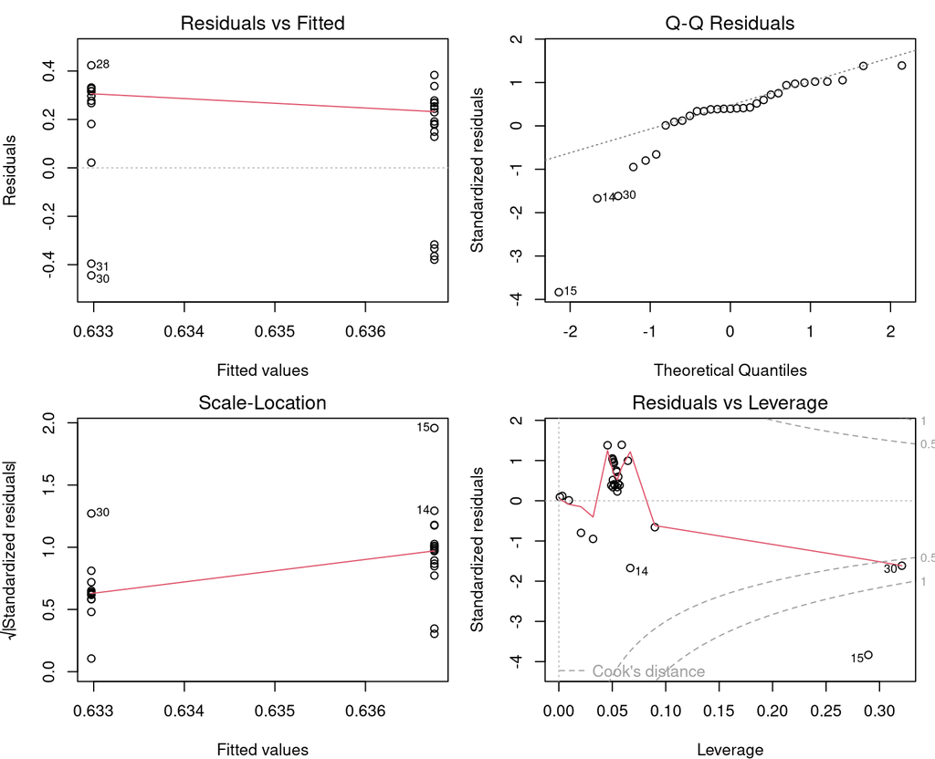

```r
diag_lm(fit_sa_2_1)
```

I wanted to know which rows carry the weight in this model. The share of each ancestry group’s total weight, for the heaviest rows:

```r
sa_weight <- sa %>%
  mutate(row = row_number(), w = 1 / se_logit^2) %>%
  group_by(ancestry) %>%
  mutate(share_of_weight = w / sum(w)) %>%
  slice_max(share_of_weight, n = 3) %>%
  ungroup() %>%
  select(row, pgs_id, ancestry, sampleset_id, auc, se_logit, share_of_weight)
kable(sa_weight, digits = 4)
```

| row | pgs_id | ancestry | sampleset_id | auc | se_logit | share_of_weight |
| --- | --- | --- | --- | --- | --- | --- |
| 15 | PGS004106 | European | PSS011236 | 0.5677 | 0.0052 | 0.2896 |
| 14 | PGS004106 | European | PSS011225 | 0.5640 | 0.0108 | 0.0668 |
| 11 | PGS002671 | European | PSS011737 | 0.7040 | 0.0110 | 0.0646 |
| 30 | PGS004106 | South Asian | PSS011249 | 0.5471 | 0.0154 | 0.3209 |
| 31 | PGS004106 | South Asian | PSS011291 | 0.5591 | 0.0291 | 0.0898 |
| 20 | PGS000729 | South Asian | PSS011749 | 0.7170 | 0.0365 | 0.0568 |

```r
sa_heavy <- sa_weight$pgs_id[1]
sa_heavy_share <- sa %>%
  mutate(w = 1 / se_logit^2) %>%
  group_by(ancestry) %>%
  summarise(share = sum(w[pgs_id == sa_heavy]) / sum(w))
```

**What we see.**

- The logit difference is -0.0038, which maps back to Δ AUC = -0.0009.
- Pipeline 1 gives 0.0007. The sign differs, and both are close to 0.
- The residual standard error σ is 21.7.
- In the weight table, the rows of PGS004106 carry 41% of the European weight and 41% of the South Asian weight.
- With a term for the score, σ is much smaller, as model 2.3 shows.

### 2.2 Add the score, no weights

- Next I let each score have its own baseline.
- With a `PGS` term, my understanding is that the ancestry coefficient compares rows of the same score.
- Here every row counts equally, whatever its sample size.

```r
fit_sa_2_2 <- lm(logit_auc ~ ancestry + PGS, data = sa)
summary(fit_sa_2_2)
```

```
Call:
lm(formula = logit_auc ~ ancestry + PGS, data = sa)

Residuals:
     Min       1Q   Median       3Q      Max
-0.09805 -0.02369  0.00643  0.02627  0.07397

Coefficients:
                    Estimate Std. Error t value Pr(>|t|)
(Intercept)           0.9636     0.0364   26.49  2.9e-15 ***
ancestrySouth Asian   0.0116     0.0182    0.64  0.53046
PGSPGS000713         -0.0421     0.0498   -0.85  0.40931
PGSPGS000729         -0.0520     0.0498   -1.04  0.31077
PGSPGS000805         -0.0543     0.0498   -1.09  0.29113
PGSPGS000864         -0.1692     0.0498   -3.40  0.00342 **
PGSPGS000868         -0.1051     0.0498   -2.11  0.04992 *
PGSPGS001295         -0.2225     0.0456   -4.88  0.00014 ***
PGSPGS001818         -0.0444     0.0498   -0.89  0.38465
PGSPGS002026         -0.0298     0.0498   -0.60  0.55796
PGSPGS002671         -0.0615     0.0498   -1.23  0.23382
PGSPGS002771          0.0689     0.0498    1.38  0.18469
PGSPGS002780         -0.1050     0.0498   -2.11  0.05023 .
PGSPGS004106         -0.7041     0.0408  -17.27  3.3e-12 ***
---
Signif. codes:  0 '***' 0.001 '**' 0.01 '*' 0.05 '.' 0.1 ' ' 1

Residual standard error: 0.0498 on 17 degrees of freedom
Multiple R-squared:  0.98,  Adjusted R-squared:  0.965
F-statistic: 64.6 on 13 and 17 DF,  p-value: 7.81e-12
```

```r
record("South Asian", "2", "2.2 lm(logit ~ ancestry + PGS)", "logit", fit_sa_2_2, sa)
show_rows("South Asian", "2.2 lm(logit ~ ancestry + PGS)")
```

| model | scale | estimate (model scale) | SE (model scale) | σ | Δ AUC | SE (AUC) | 95% CI | note |
| --- | --- | --- | --- | --- | --- | --- | --- | --- |
| 2.2 lm(logit ~ ancestry + PGS) | logit | 0.01165 | 0.01819 | 0.0498 | 0.00243 | 0.00379 | -0.0050 to 0.0099 |  |

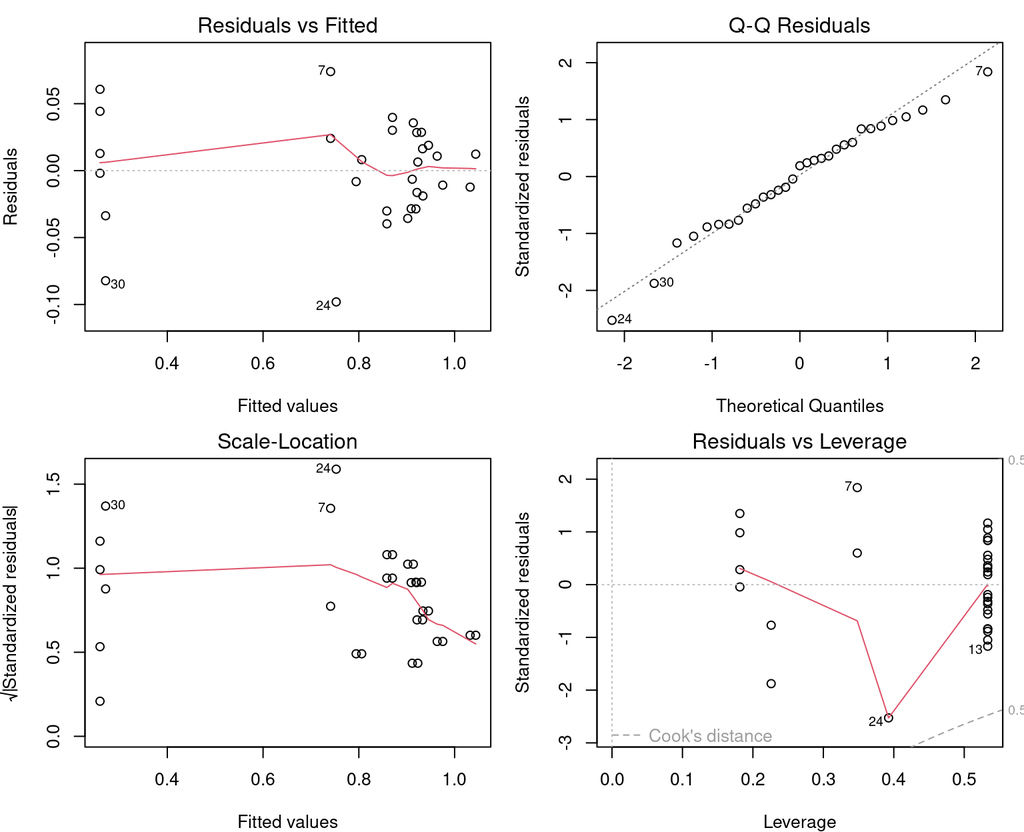

```r
diag_lm(fit_sa_2_2)
```

**What we see.**

- The `PGS` rows of the summary are each score’s logit relative to the first score, PGS000330.
- Δ AUC is now 0.0024.
- This model does not use the weights, so a small sample set counts as much as a large one.

### 2.3 Add the score, with weights

I put the weights back into the same model.

```r
fit_sa_2_3 <- lm(logit_auc ~ ancestry + PGS, data = sa, weights = 1 / se_logit^2)
summary(fit_sa_2_3)
```

```
Call:
lm(formula = logit_auc ~ ancestry + PGS, data = sa, weights = 1/se_logit^2)

Weighted Residuals:
   Min     1Q Median     3Q    Max
-4.972 -0.551  0.053  1.168  3.316

Coefficients:
                    Estimate Std. Error t value Pr(>|t|)
(Intercept)          0.97381    0.02216   43.94  < 2e-16 ***
ancestrySouth Asian -0.00309    0.01837   -0.17  0.86827
PGSPGS000713        -0.06437    0.03249   -1.98  0.06396 .
PGSPGS000729        -0.06582    0.03237   -2.03  0.05791 .
PGSPGS000805        -0.08616    0.03228   -2.67  0.01618 *
PGSPGS000864        -0.18481    0.03168   -5.83    2e-05 ***
PGSPGS000868        -0.13838    0.03192   -4.33  0.00045 ***
PGSPGS001295        -0.21922    0.08113   -2.70  0.01511 *
PGSPGS001818        -0.07647    0.03235   -2.36  0.03026 *
PGSPGS002026        -0.05387    0.03251   -1.66  0.11593
PGSPGS002671        -0.10075    0.03065   -3.29  0.00435 **
PGSPGS002771         0.05037    0.03330    1.51  0.14877
PGSPGS002780        -0.14665    0.03192   -4.59  0.00026 ***
PGSPGS004106        -0.70538    0.02363  -29.85    4e-16 ***
---
Signif. codes:  0 '***' 0.001 '**' 0.01 '*' 0.05 '.' 0.1 ' ' 1

Residual standard error: 2.01 on 17 degrees of freedom
Multiple R-squared:  0.995, Adjusted R-squared:  0.991
F-statistic:  259 on 13 and 17 DF,  p-value: <2e-16
```

```r
record("South Asian", "2", "2.3 lm(logit ~ ancestry + PGS), weighted", "logit", fit_sa_2_3, sa)
show_rows("South Asian", "2.3 lm(logit ~ ancestry + PGS), weighted")
```

| model | scale | estimate (model scale) | SE (model scale) | σ | Δ AUC | SE (AUC) | 95% CI | note |
| --- | --- | --- | --- | --- | --- | --- | --- | --- |
| 2.3 lm(logit ~ ancestry + PGS), weighted | logit | -0.00309 | 0.01837 | 2.0077 | -0.00065 | 0.00386 | -0.0082 to 0.0069 |  |

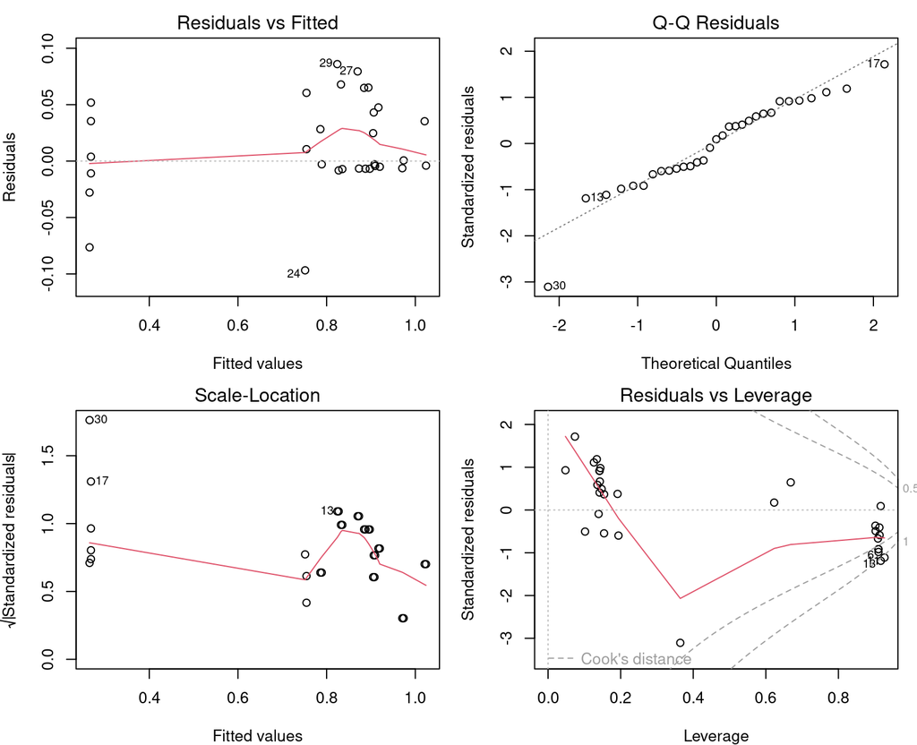

```r
diag_lm(fit_sa_2_3)
```

**What we see.**

- Δ AUC = -0.0006, against 0.0007 from pipeline 1. The sign differs, and both are close to 0.
- σ drops from 21.7 in 2.1 to 2.01.
- σ² here (4.03) is similar to Q / df in pipeline 1 (4.42).
- The AUC-scale version of this model is 3.3.

### 2.4 Add a random effect for the sample set

- Rows from the same sample set share people, so I would expect them to share a shift up or down that has nothing to do with ancestry.
- `(1 | cohort)` gives each sample set its own random shift.

```r
fit_sa_2_4 <- lmer(logit_auc ~ ancestry + PGS + (1 | cohort), data = sa, weights = 1 / se_logit^2)
summary(fit_sa_2_4)
```

```
Linear mixed model fit by REML ['lmerMod']
Formula: logit_auc ~ ancestry + PGS + (1 | cohort)
   Data: sa
Weights: 1/se_logit^2

REML criterion at convergence: -57.8

Scaled residuals:
    Min      1Q  Median      3Q     Max
-1.9341 -0.2569  0.0317  0.2620  1.3864

Random effects:
 Groups   Name        Variance Std.Dev.
 cohort   (Intercept) 0.00169  0.0411
 Residual             0.54218  0.7363
Number of obs: 31, groups:  cohort, 11

Fixed effects:
                    Estimate Std. Error t value
(Intercept)           1.0178     0.0337   30.18
ancestrySouth Asian  -0.0493     0.0300   -1.64
PGSPGS000713         -0.0645     0.0119   -5.41
PGSPGS000729         -0.0666     0.0119   -5.61
PGSPGS000805         -0.0865     0.0118   -7.31
PGSPGS000864         -0.1850     0.0116  -15.92
PGSPGS000868         -0.1387     0.0117  -11.85
PGSPGS001295         -0.2553     0.0498   -5.13
PGSPGS001818         -0.0768     0.0119   -6.47
PGSPGS002026         -0.0543     0.0119   -4.55
PGSPGS002671         -0.1002     0.0112   -8.91
PGSPGS002771          0.0496     0.0122    4.06
PGSPGS002780         -0.1466     0.0117  -12.52
PGSPGS004106         -0.7386     0.0355  -20.83
```

```r
ranef(fit_sa_2_4)
```

```
$cohort
          (Intercept)
PSS004314   0.0148182
PSS004315  -0.0162881
PSS004316   0.0014700
PSS011225  -0.0208994
PSS011236  -0.0068484
PSS011249  -0.0381413
PSS011265   0.0219384
PSS011278   0.0380497
PSS011291   0.0059010
PSS011737  -0.0485284
PSS011749   0.0485284

with conditional variances for "cohort"
```

```r
record("South Asian", "2", "2.4 lmer(logit ~ ancestry + PGS + (1|cohort)), weighted", "logit", fit_sa_2_4, sa)
show_rows("South Asian", "2.4 lmer(logit ~ ancestry + PGS + (1|cohort)), weighted")
```

| model | scale | estimate (model scale) | SE (model scale) | σ | Δ AUC | SE (AUC) | 95% CI | note |
| --- | --- | --- | --- | --- | --- | --- | --- | --- |
| 2.4 lmer(logit ~ ancestry + PGS + (1\|cohort)), weighted | logit | -0.04927 | 0.02997 | 0.73633 | -0.01027 | 0.00625 | -0.0225 to 0.0020 |  |

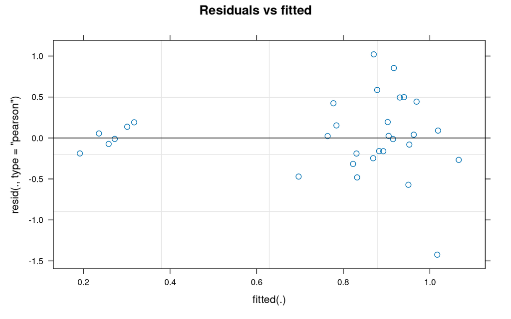

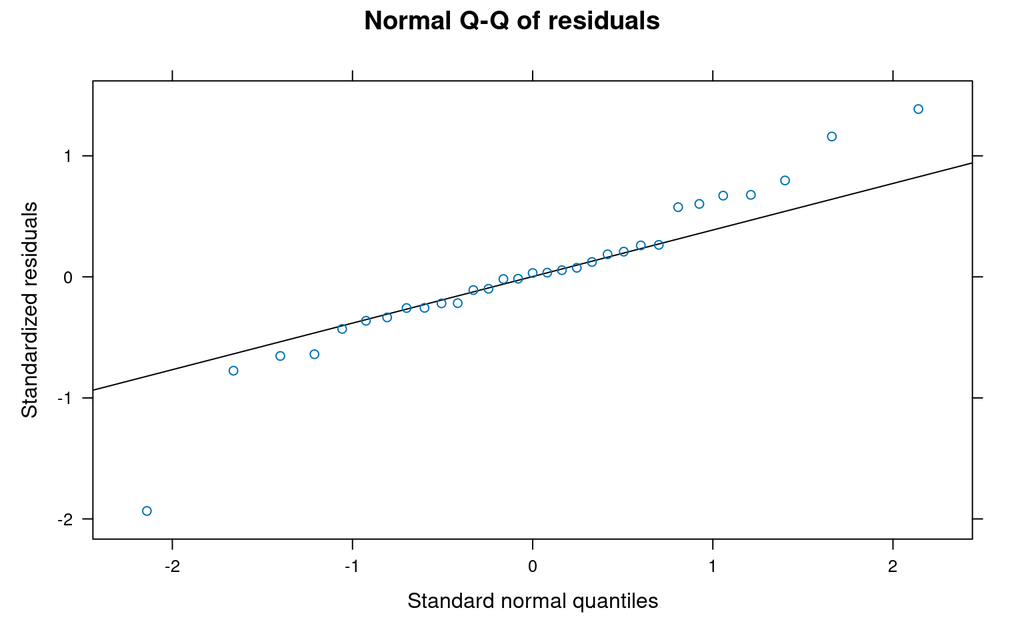

```r
diag_lmer(fit_sa_2_4)
```

**What we see.**

- Adding the sample set moves the estimate: Δ AUC goes from -0.0006 to -0.0103, and the SE grows.
- In `ranef()`, the two sample sets with the most rows, PSS011737 (European) and PSS011749 (South Asian), get shifts of opposite sign.
- 11 scores were measured only in these two sets.
- I am not sure how to interpret this change in the estimate (open question 2).

My understanding is that `lmer`, like `lm`, multiplies the variances by its own residual scale (`Residual` in the summary).

### 2.5 Score as a random effect too

- Here, instead of a fixed baseline per score, I let the scores’ baselines come from a distribution, `(1 | PGS)`.
- As I understand it, the fixed intercept is now the logit of a typical score, so I map Δ AUC back at that typical score.

```r
fit_sa_2_5 <- lmer(logit_auc ~ ancestry + (1 | PGS) + (1 | cohort), data = sa, weights = 1 / se_logit^2)
summary(fit_sa_2_5)
```

```
Linear mixed model fit by REML ['lmerMod']
Formula: logit_auc ~ ancestry + (1 | PGS) + (1 | cohort)
   Data: sa
Weights: 1/se_logit^2

REML criterion at convergence: -60.7

Scaled residuals:
    Min      1Q  Median      3Q     Max
-1.9076 -0.2743 -0.0022  0.2488  1.3967

Random effects:
 Groups   Name        Variance Std.Dev.
 PGS      (Intercept) 0.03572  0.1890
 cohort   (Intercept) 0.00178  0.0422
 Residual             0.54404  0.7376
Number of obs: 31, groups:  PGS, 13; cohort, 11

Fixed effects:
                    Estimate Std. Error t value
(Intercept)           0.8595     0.0598   14.37
ancestrySouth Asian  -0.0463     0.0306   -1.51

Correlation of Fixed Effects:
            (Intr)
ancstrySthA -0.232
```

```r
record("South Asian", "2", "2.5 lmer(logit ~ ancestry + (1|PGS) + (1|cohort)), weighted", "logit", fit_sa_2_5, sa)
show_rows("South Asian", "2.5 lmer(logit ~ ancestry + (1|PGS) + (1|cohort)), weighted")
```

| model | scale | estimate (model scale) | SE (model scale) | σ | Δ AUC | SE (AUC) | 95% CI | note |
| --- | --- | --- | --- | --- | --- | --- | --- | --- |
| 2.5 lmer(logit ~ ancestry + (1\|PGS) + (1\|cohort)), weighted | logit | -0.04632 | 0.03063 | 0.73759 | -0.00977 | 0.00647 | -0.0224 to 0.0029 |  |

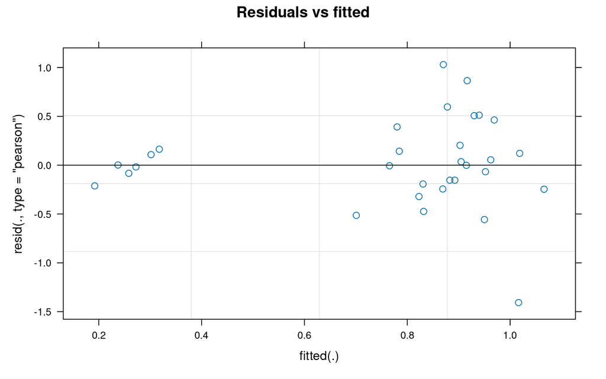

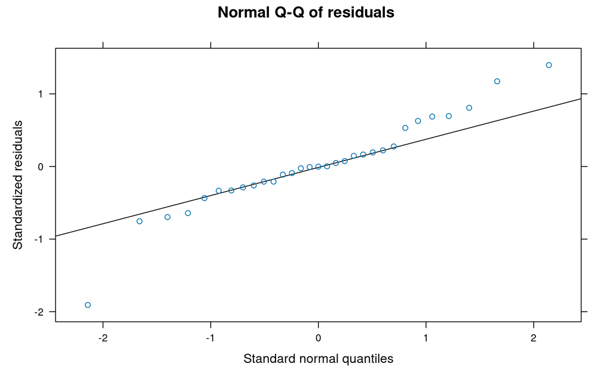

```r
diag_lmer(fit_sa_2_5)
```

**What we see.**

- Δ AUC = -0.0098, close to 2.4, where the score is a fixed term.

### Pipeline 2 so far

```r
sa_models_p2 <- est_tbl %>% filter(comparison == "South Asian", pipeline %in% c("1", "2")) %>% pull(model)
show_rows("South Asian", sa_models_p2)
```

| model | scale | estimate (model scale) | SE (model scale) | σ | Δ AUC | SE (AUC) | 95% CI | note |
| --- | --- | --- | --- | --- | --- | --- | --- | --- |
| 1. IVW stage 1 → stage 2 | AUC | 0.00072 | 0.00199 | NA | 0.00072 | 0.00199 | -0.0032 to 0.0046 |  |
| 2.1 lm(logit ~ ancestry), weighted | logit | -0.00379 | 0.19845 | 21.69675 | -0.00086 | 0.04495 | -0.0890 to 0.0872 |  |
| 2.2 lm(logit ~ ancestry + PGS) | logit | 0.01165 | 0.01819 | 0.04980 | 0.00243 | 0.00379 | -0.0050 to 0.0099 |  |
| 2.3 lm(logit ~ ancestry + PGS), weighted | logit | -0.00309 | 0.01837 | 2.00774 | -0.00065 | 0.00386 | -0.0082 to 0.0069 |  |
| 2.4 lmer(logit ~ ancestry + PGS + (1\|cohort)), weighted | logit | -0.04927 | 0.02997 | 0.73633 | -0.01027 | 0.00625 | -0.0225 to 0.0020 |  |
| 2.5 lmer(logit ~ ancestry + (1\|PGS) + (1\|cohort)), weighted | logit | -0.04632 | 0.03063 | 0.73759 | -0.00977 | 0.00647 | -0.0224 to 0.0029 |  |

## Pipeline 3: AUC scale, `lm` then `lmer`

- The same five models, with AUC as the outcome and weights 1 / SE(AUC)².
- There is no back-transformation: the coefficient is already a Δ AUC.
- What I want to know here is whether the scale changes the story.

```r
fit_sa_3_1 <- lm(auc ~ ancestry, data = sa, weights = 1 / se_auc^2)
fit_sa_3_2 <- lm(auc ~ ancestry + PGS, data = sa)
fit_sa_3_3 <- lm(auc ~ ancestry + PGS, data = sa, weights = 1 / se_auc^2)
fit_sa_3_4 <- lmer(auc ~ ancestry + PGS + (1 | cohort), data = sa, weights = 1 / se_auc^2)
fit_sa_3_5 <- lmer(auc ~ ancestry + (1 | PGS) + (1 | cohort), data = sa, weights = 1 / se_auc^2)
```

### 3.1 Ancestry only

```r
summary(fit_sa_3_1)
```

```
Call:
lm(formula = auc ~ ancestry, data = sa, weights = 1/se_auc^2)

Weighted Residuals:
   Min     1Q Median     3Q    Max
-74.47   1.73   7.31  15.22  28.35

Coefficients:
                    Estimate Std. Error t value Pr(>|t|)
(Intercept)          0.66267    0.01331   49.77   <2e-16 ***
ancestrySouth Asian  0.00238    0.04311    0.06     0.96
---
Signif. codes:  0 '***' 0.001 '**' 0.01 '*' 0.05 '.' 0.1 ' ' 1

Residual standard error: 21.6 on 29 degrees of freedom
Multiple R-squared:  0.000105,  Adjusted R-squared:  -0.0344
F-statistic: 0.00306 on 1 and 29 DF,  p-value: 0.956
```

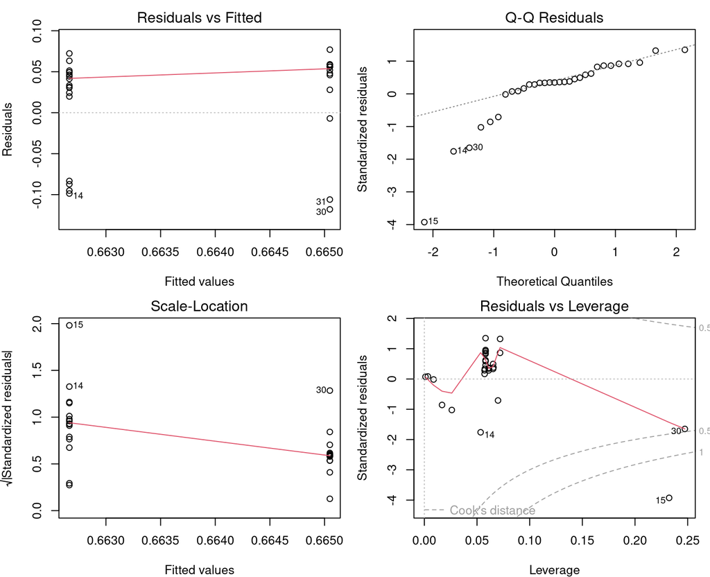

```r
diag_lm(fit_sa_3_1)
```

### 3.2 Add the score, no weights

```r
summary(fit_sa_3_2)
```

```
Call:
lm(formula = auc ~ ancestry + PGS, data = sa)

Residuals:
     Min       1Q   Median       3Q      Max
-0.02095 -0.00517  0.00167  0.00564  0.01583

Coefficients:
                    Estimate Std. Error t value Pr(>|t|)
(Intercept)          0.72417    0.00809   89.52  < 2e-16 ***
ancestrySouth Asian  0.00166    0.00404    0.41  0.68652
PGSPGS000713        -0.00850    0.01108   -0.77  0.45337
PGSPGS000729        -0.01050    0.01108   -0.95  0.35643
PGSPGS000805        -0.01100    0.01108   -0.99  0.33459
PGSPGS000864        -0.03500    0.01108   -3.16  0.00572 **
PGSPGS000868        -0.02150    0.01108   -1.94  0.06902 .
PGSPGS001295        -0.04682    0.01013   -4.62  0.00024 ***
PGSPGS001818        -0.00900    0.01108   -0.81  0.42772
PGSPGS002026        -0.00600    0.01108   -0.54  0.59506
PGSPGS002671        -0.01250    0.01108   -1.13  0.27477
PGSPGS002771         0.01350    0.01108    1.22  0.23956
PGSPGS002780        -0.02150    0.01108   -1.94  0.06902 .
PGSPGS004106        -0.15929    0.00907  -17.56  2.5e-12 ***
---
Signif. codes:  0 '***' 0.001 '**' 0.01 '*' 0.05 '.' 0.1 ' ' 1

Residual standard error: 0.0111 on 17 degrees of freedom
Multiple R-squared:  0.981, Adjusted R-squared:  0.966
F-statistic: 67.2 on 13 and 17 DF,  p-value: 5.66e-12
```

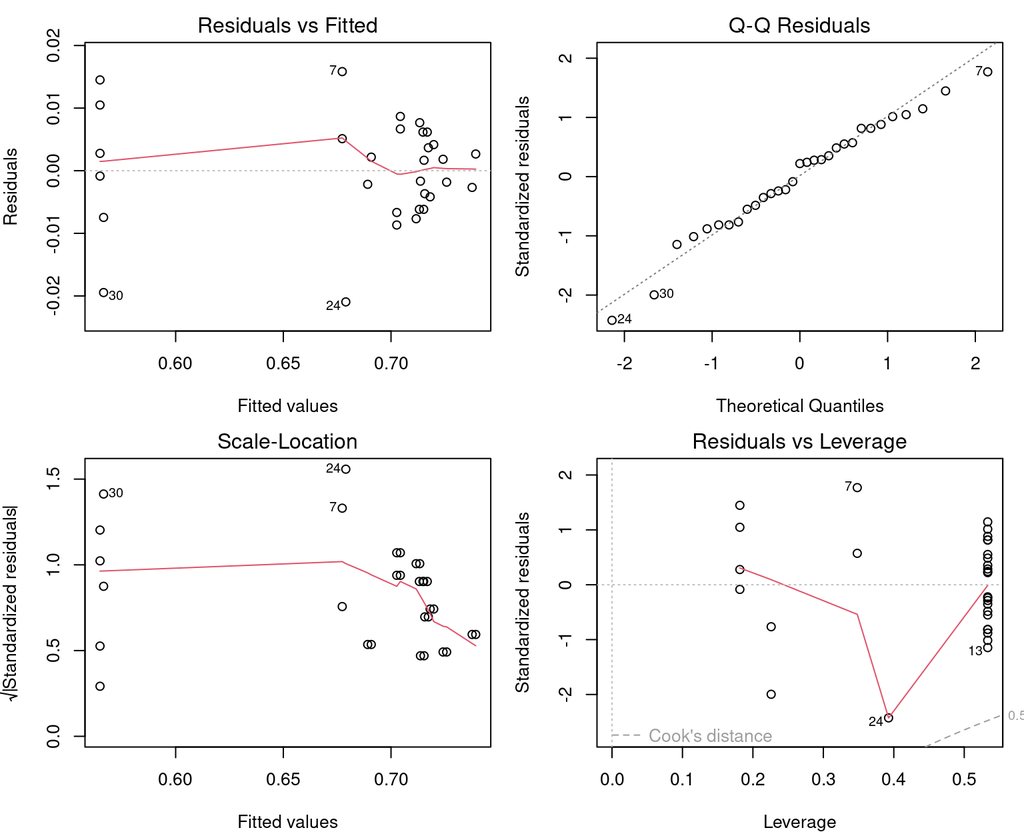

```r
diag_lm(fit_sa_3_2)
```

### 3.3 Add the score, with weights

```r
summary(fit_sa_3_3)
```

```
Call:
lm(formula = auc ~ ancestry + PGS, data = sa, weights = 1/se_auc^2)

Weighted Residuals:
   Min     1Q Median     3Q    Max
-5.312 -0.520  0.104  1.020  3.356

Coefficients:
                     Estimate Std. Error t value Pr(>|t|)
(Intercept)          0.725762   0.004425  164.00  < 2e-16 ***
ancestrySouth Asian  0.000716   0.004012    0.18  0.86047
PGSPGS000713        -0.012980   0.006585   -1.97  0.06521 .
PGSPGS000729        -0.013308   0.006562   -2.03  0.05854 .
PGSPGS000805        -0.017435   0.006574   -2.65  0.01677 *
PGSPGS000864        -0.038265   0.006586   -5.81 0.000021 ***
PGSPGS000868        -0.028335   0.006574   -4.31  0.00047 ***
PGSPGS001295        -0.045541   0.017583   -2.59  0.01906 *
PGSPGS001818        -0.015435   0.006574   -2.35  0.03125 *
PGSPGS002026        -0.010834   0.006574   -1.65  0.11771
PGSPGS002671        -0.020421   0.006248   -3.27  0.00453 **
PGSPGS002771         0.009904   0.006562    1.51  0.14962
PGSPGS002780        -0.030044   0.006586   -4.56  0.00028 ***
PGSPGS004106        -0.159159   0.004868  -32.70  < 2e-16 ***
---
Signif. codes:  0 '***' 0.001 '**' 0.01 '*' 0.05 '.' 0.1 ' ' 1

Residual standard error: 2.01 on 17 degrees of freedom
Multiple R-squared:  0.995, Adjusted R-squared:  0.991
F-statistic:  256 on 13 and 17 DF,  p-value: <2e-16
```

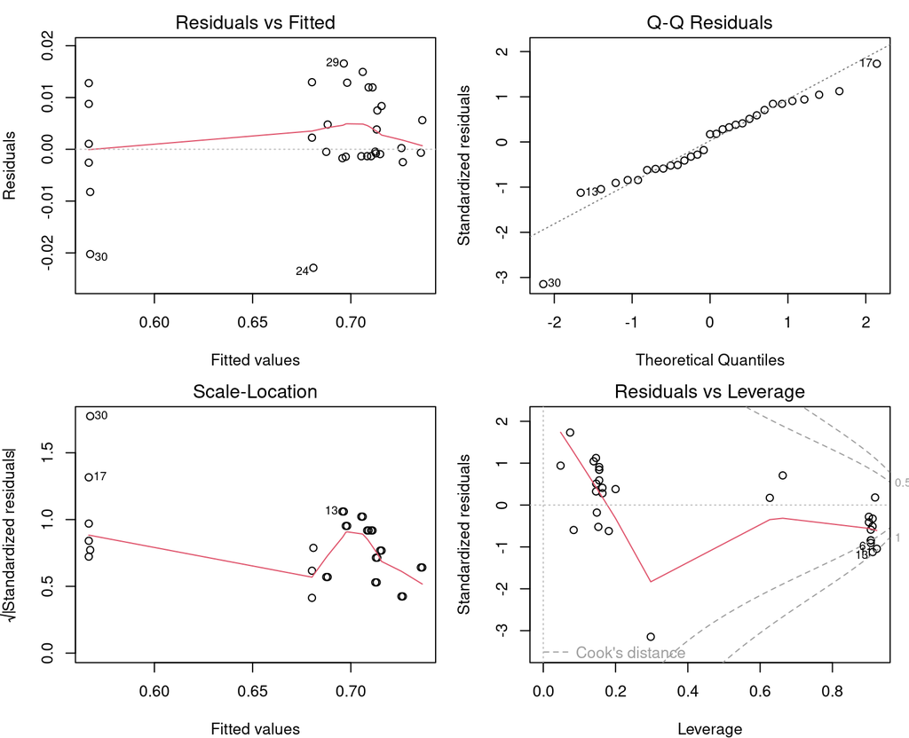

```r
diag_lm(fit_sa_3_3)
```

**What we see.**

- This model gives Δ AUC = 0.000716, against 0.000717 from pipeline 1. The two are almost the same.

The SE is a different story. It is 0.0040, against 0.0020 in pipeline 1. I divided it by σ:

```r
c(
  se_lm = get_est("South Asian", "3.3 lm(AUC ~ ancestry + PGS), weighted", "se"),
  sigma = sigma(fit_sa_3_3),
  se_lm_divided_by_sigma = get_est("South Asian", "3.3 lm(AUC ~ ancestry + PGS), weighted", "se") / sigma(fit_sa_3_3),
  se_pipeline_1 = sa_p1[["se"]]
)
```

```
                 se_lm                  sigma se_lm_divided_by_sigma          se_pipeline_1
             0.0040124              2.0137905              0.0019924              0.0019925
```

- Once σ is taken out, the SE is close to the pipeline 1 SE.
- σ for this model is 2.0.

### 3.4 Add a random effect for the sample set

```r
summary(fit_sa_3_4)
```

```
Linear mixed model fit by REML ['lmerMod']
Formula: auc ~ ancestry + PGS + (1 | cohort)
   Data: sa
Weights: 1/se_auc^2

REML criterion at convergence: -109.9

Scaled residuals:
   Min     1Q Median     3Q    Max
-1.950 -0.278  0.004  0.276  1.405

Random effects:
 Groups   Name        Variance Std.Dev.
 cohort   (Intercept) 0.000092 0.00959
 Residual             0.559140 0.74776
Number of obs: 31, groups:  cohort, 11

Fixed effects:
                    Estimate Std. Error t value
(Intercept)          0.73603    0.00782   94.10
ancestrySouth Asian -0.01232    0.00701   -1.76
PGSPGS000713        -0.01304    0.00245   -5.33
PGSPGS000729        -0.01347    0.00244   -5.53
PGSPGS000805        -0.01755    0.00244   -7.19
PGSPGS000864        -0.03832    0.00245  -15.67
PGSPGS000868        -0.02845    0.00244  -11.65
PGSPGS001295        -0.05364    0.01138   -4.71
PGSPGS001818        -0.01555    0.00244   -6.37
PGSPGS002026        -0.01094    0.00244   -4.48
PGSPGS002671        -0.02037    0.00232   -8.78
PGSPGS002771         0.00974    0.00244    4.00
PGSPGS002780        -0.03010    0.00245  -12.31
PGSPGS004106        -0.16665    0.00824  -20.24
```

```
optimizer (nloptwrap) convergence code: 0 (OK)
Model failed to converge with max|grad| = 0.00544554 (tol = 0.002, component 1)
  See ?lme4::convergence and ?lme4::troubleshooting.
```

```r
ranef(fit_sa_3_4)
```

```
$cohort
           (Intercept)
PSS004314  0.003399427
PSS004315 -0.003445846
PSS004316  0.000046419
PSS011225 -0.005133232
PSS011236 -0.001706676
PSS011249 -0.009166475
PSS011265  0.005270798
PSS011278  0.009192883
PSS011291  0.001542703
PSS011737 -0.011069618
PSS011749  0.011069618

with conditional variances for "cohort"
```

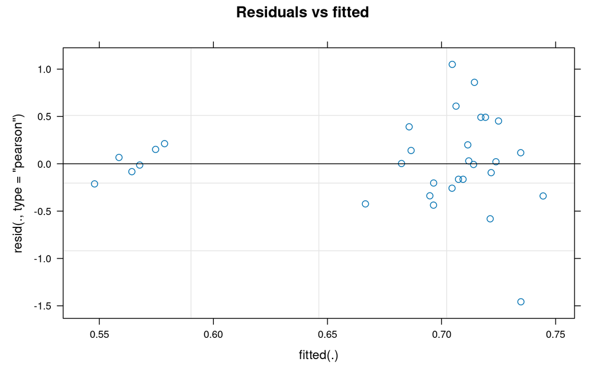

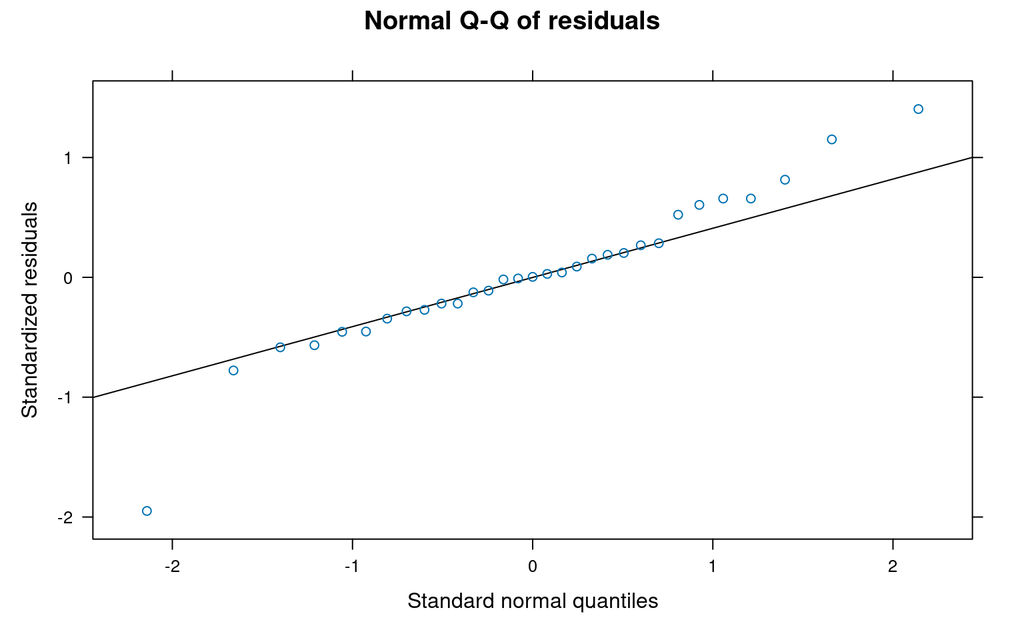

```r
diag_lmer(fit_sa_3_4)
```

### 3.5 Score as a random effect too

```r
summary(fit_sa_3_5)
```

```
Linear mixed model fit by REML ['lmerMod']
Formula: auc ~ ancestry + (1 | PGS) + (1 | cohort)
   Data: sa
Weights: 1/se_auc^2

REML criterion at convergence: -145.4

Scaled residuals:
    Min      1Q  Median      3Q     Max
-1.8991 -0.1913 -0.0119  0.2515  1.2734

Random effects:
 Groups   Name        Variance Std.Dev.
 PGS      (Intercept) 0.000203 0.0142
 cohort   (Intercept) 0.003990 0.0632
 Residual             0.596750 0.7725
Number of obs: 31, groups:  PGS, 13; cohort, 11

Fixed effects:
                    Estimate Std. Error t value
(Intercept)           0.6305     0.0256   24.64
ancestrySouth Asian  -0.0043     0.0399   -0.11

Correlation of Fixed Effects:
            (Intr)
ancstrySthA -0.573
```

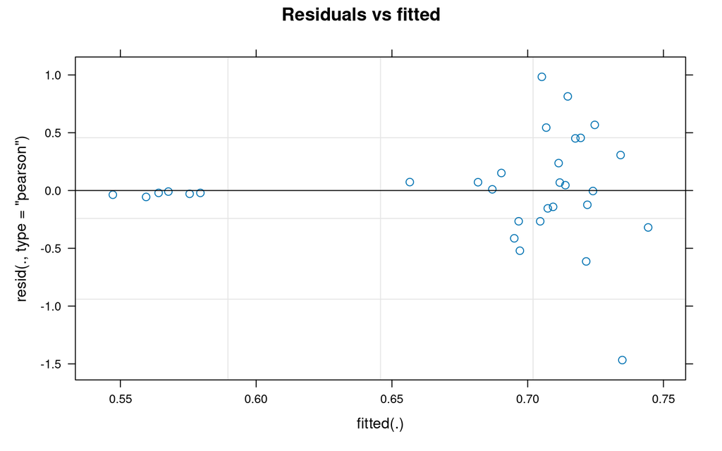

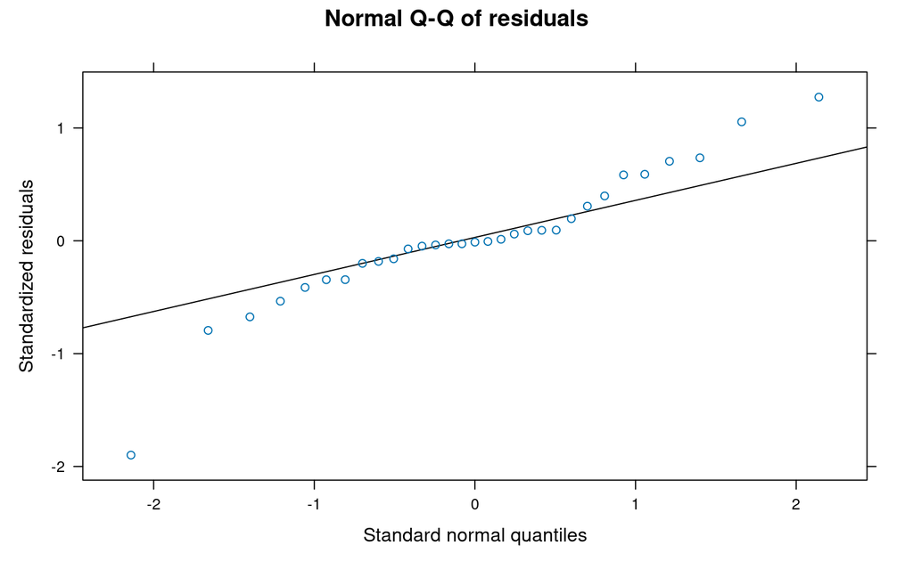

```r
diag_lmer(fit_sa_3_5)
```

### Pipeline 3 so far

```r
sa_models_p3 <- est_tbl %>% filter(comparison == "South Asian", pipeline %in% c("1", "2", "3")) %>% pull(model)
show_rows("South Asian", sa_models_p3)
```

| model | scale | estimate (model scale) | SE (model scale) | σ | Δ AUC | SE (AUC) | 95% CI | note |
| --- | --- | --- | --- | --- | --- | --- | --- | --- |
| 1. IVW stage 1 → stage 2 | AUC | 0.00072 | 0.00199 | NA | 0.00072 | 0.00199 | -0.0032 to 0.0046 |  |
| 2.1 lm(logit ~ ancestry), weighted | logit | -0.00379 | 0.19845 | 21.69675 | -0.00086 | 0.04495 | -0.0890 to 0.0872 |  |
| 2.2 lm(logit ~ ancestry + PGS) | logit | 0.01165 | 0.01819 | 0.04980 | 0.00243 | 0.00379 | -0.0050 to 0.0099 |  |
| 2.3 lm(logit ~ ancestry + PGS), weighted | logit | -0.00309 | 0.01837 | 2.00774 | -0.00065 | 0.00386 | -0.0082 to 0.0069 |  |
| 2.4 lmer(logit ~ ancestry + PGS + (1\|cohort)), weighted | logit | -0.04927 | 0.02997 | 0.73633 | -0.01027 | 0.00625 | -0.0225 to 0.0020 |  |
| 2.5 lmer(logit ~ ancestry + (1\|PGS) + (1\|cohort)), weighted | logit | -0.04632 | 0.03063 | 0.73759 | -0.00977 | 0.00647 | -0.0224 to 0.0029 |  |
| 3.1 lm(AUC ~ ancestry), weighted | AUC | 0.00238 | 0.04311 | 21.64594 | 0.00238 | 0.04311 | -0.0821 to 0.0869 |  |
| 3.2 lm(AUC ~ ancestry + PGS) | AUC | 0.00166 | 0.00404 | 0.01108 | 0.00166 | 0.00404 | -0.0063 to 0.0096 |  |
| 3.3 lm(AUC ~ ancestry + PGS), weighted | AUC | 0.00072 | 0.00401 | 2.01379 | 0.00072 | 0.00401 | -0.0071 to 0.0086 |  |
| 3.4 lmer(AUC ~ ancestry + PGS + (1\|cohort)), weighted | AUC | -0.01232 | 0.00701 | 0.74776 | -0.01232 | 0.00701 | -0.0261 to 0.0014 | convergence warning |
| 3.5 lmer(AUC ~ ancestry + (1\|PGS) + (1\|cohort)), weighted | AUC | -0.00430 | 0.03990 | 0.77250 | -0.00430 | 0.03990 | -0.0825 to 0.0739 |  |

**What we see.**

- For 3.1 to 3.4, the AUC-scale estimates are close to the logit-scale ones in pipeline 2.
- Models with a term for the score, and no sample-set term, land near pipeline 1.
- In 3.4, adding the sample set pulls the estimate down to -0.012, against -0.010 in 2.4. `lmer` gave a convergence warning for 3.4.
- 3.5, where the score is also random, gives -0.004, against -0.010 in 2.5, and its SE is much larger than in 3.4. The variance components:

```r
VarCorr(fit_sa_3_5)
```

```
 Groups   Name        Std.Dev.
 PGS      (Intercept) 0.0142
 cohort   (Intercept) 0.0632
 Residual             0.7725
```

```r
sa_vc35 <- as.data.frame(VarCorr(fit_sa_3_5))
```

- On the AUC scale, the sample-set SD is 0.063 and the score SD is 0.014. On the logit scale (2.5) it was the other way round.

## Pipeline 4: logit scale, `rma.mv`

- `rma.mv` from metafor seems to be built for this kind of data: the docs point to it for multilevel models ([metafor: rma() vs lm(), lme(), lmer()](https://www.metafor-project.org/doku.php/tips:rma_vs_lm_lme_lmer)).
- My understanding is that it takes each row’s variance, SE², as known.
- Extra scatter shows up in the output either as the variance of a random effect (`sigma^2`) or in the test of residual heterogeneity (QE).
- For `rma.mv`, the docs suggest `test = "t"` and say “one should also set `dfs="contain"`” ([metafor: recommended practices](https://wviechtb.github.io/metafor/reference/misc-recs.html)). I use the default z-tests, and every interval on this page is the estimate ± 1.96 × SE, so the intervals may be too narrow.

The models mirror pipeline 2. I have no unweighted version, because `rma.mv` always uses the SEs.

```r
fit_sa_4_1 <- rma.mv(logit_auc, se_logit^2, mods = ~ ancestry, data = sa)
fit_sa_4_2 <- rma.mv(logit_auc, se_logit^2, mods = ~ ancestry + PGS, data = sa)
fit_sa_4_3 <- rma.mv(logit_auc, se_logit^2, mods = ~ ancestry + PGS, random = ~ 1 | cohort, data = sa)
fit_sa_4_4 <- rma.mv(logit_auc, se_logit^2, mods = ~ ancestry, random = list(~ 1 | PGS, ~ 1 | cohort), data = sa)
```

### 4.1 Ancestry only

```r
fit_sa_4_1
```

```
Multivariate Meta-Analysis Model (k = 31; method: REML)

Variance Components: none

Test for Residual Heterogeneity:
QE(df = 29) = 13651.7190, p-val < .0001

Test of Moderators (coefficient 2):
QM(df = 1) = 0.1714, p-val = 0.6789

Model Results:

                     estimate      se      zval    pval    ci.lb   ci.ub
intrcpt                0.6368  0.0028  227.6418  <.0001   0.6313  0.6422  ***
ancestrySouth Asian   -0.0038  0.0091   -0.4140  0.6789  -0.0217  0.0141

---
Signif. codes:  0 '***' 0.001 '**' 0.01 '*' 0.05 '.' 0.1 ' ' 1
```

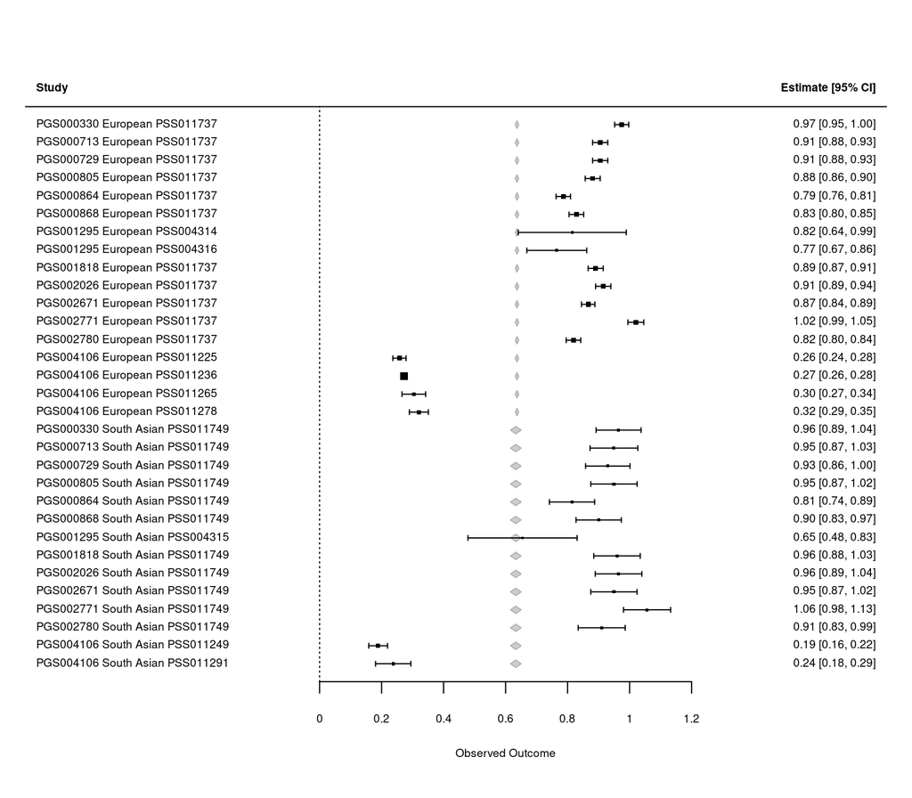

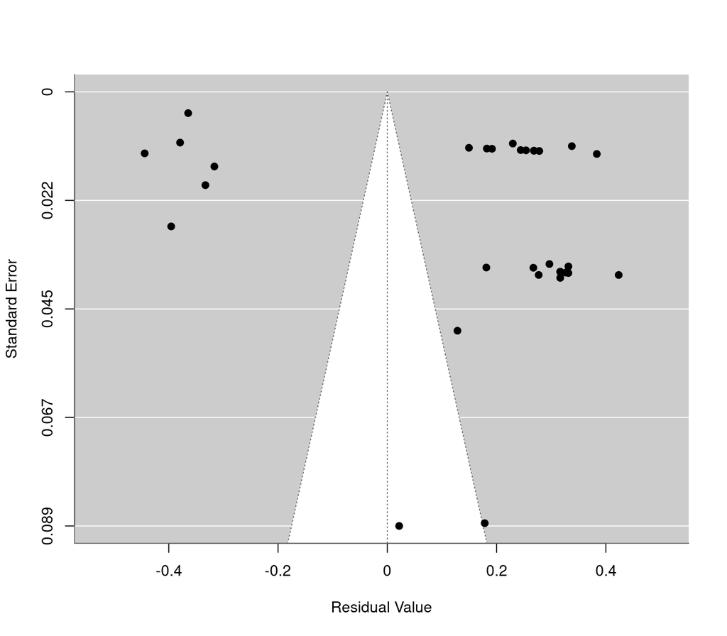

```r
diag_rma(fit_sa_4_1, sa)
```

**How to read these two plots.** They are metafor’s `forest()` and `funnel()`, and I show them for every `rma.mv` model on this page.

- Forest plot: each row is one AUC from the master table, on the scale of the model, with its 95% interval. The model has moderators, so there is no summary diamond. Instead, “the fitted value for each study is added as a polygon to the plot” ([metafor: forest.rma](https://wviechtb.github.io/metafor/reference/forest.rma.html)). Here a study is a row.
- Funnel plot: the x-axis is not the logit AUC. With moderators, “the plot shows the residuals on the x-axis against their corresponding standard errors” ([metafor: funnel](https://wviechtb.github.io/metafor/reference/funnel.html)).

**What we see.**

- The logit estimate is the same as in 2.1 (-0.0038).
- The SE is 0.0091 here, against 0.1984 from `lm`. The ratio of the two is σ from 2.1.
- σ² from `lm` is equal to QE divided by its degrees of freedom:

```r
c(QE = fit_sa_4_1$QE, df = fit_sa_4_1$k - fit_sa_4_1$p, QE_over_df = fit_sa_4_1$QE / (fit_sa_4_1$k - fit_sa_4_1$p), sigma_squared_lm = sigma(fit_sa_2_1)^2)
```

```
              QE               df       QE_over_df sigma_squared_lm
        13651.72            29.00           470.75           470.75
```

**What the metafor docs say.**

- With weights 1 / SE², `lm`, `lme` and `lmer` “assume that the sampling variances are known only up to a proportionality constant” ([metafor: rma() vs lm(), lme(), lmer()](https://www.metafor-project.org/doku.php/tips:rma_vs_lm_lme_lmer)).
- In the `lm` example on that page, multiplying the variances by a constant “does not affect the model estimate, but only the corresponding standard error”. The example shows the `lm` SE divided by σ giving the `rma` SE, which is what I see here.
- The page says this for the `lm` example. In its `lme` and `lmer` examples the estimate differs from the `rma` one as well.

### 4.2 Add the score

```r
fit_sa_4_2
```

```
Multivariate Meta-Analysis Model (k = 31; method: REML)

Variance Components: none

Test for Residual Heterogeneity:
QE(df = 17) = 68.5277, p-val < .0001

Test of Moderators (coefficients 2:14):
QM(df = 13) = 13583.3628, p-val < .0001

Model Results:

                     estimate      se      zval    pval    ci.lb    ci.ub
intrcpt                0.9738  0.0110   88.2289  <.0001   0.9522   0.9954  ***
ancestrySouth Asian   -0.0031  0.0092   -0.3381  0.7353  -0.0210   0.0148
PGSPGS000713          -0.0644  0.0162   -3.9780  <.0001  -0.0961  -0.0327  ***
PGSPGS000729          -0.0658  0.0161   -4.0829  <.0001  -0.0974  -0.0342  ***
PGSPGS000805          -0.0862  0.0161   -5.3592  <.0001  -0.1177  -0.0547  ***
PGSPGS000864          -0.1848  0.0158  -11.7127  <.0001  -0.2157  -0.1539  ***
PGSPGS000868          -0.1384  0.0159   -8.7036  <.0001  -0.1695  -0.1072  ***
PGSPGS001295          -0.2192  0.0404   -5.4250  <.0001  -0.2984  -0.1400  ***
PGSPGS001818          -0.0765  0.0161   -4.7458  <.0001  -0.1080  -0.0449  ***
PGSPGS002026          -0.0539  0.0162   -3.3261  0.0009  -0.0856  -0.0221  ***
PGSPGS002671          -0.1007  0.0153   -6.6002  <.0001  -0.1307  -0.0708  ***
PGSPGS002771           0.0504  0.0166    3.0368  0.0024   0.0179   0.0829   **
PGSPGS002780          -0.1466  0.0159   -9.2231  <.0001  -0.1778  -0.1155  ***
PGSPGS004106          -0.7054  0.0118  -59.9384  <.0001  -0.7285  -0.6823  ***

---
Signif. codes:  0 '***' 0.001 '**' 0.01 '*' 0.05 '.' 0.1 ' ' 1
```

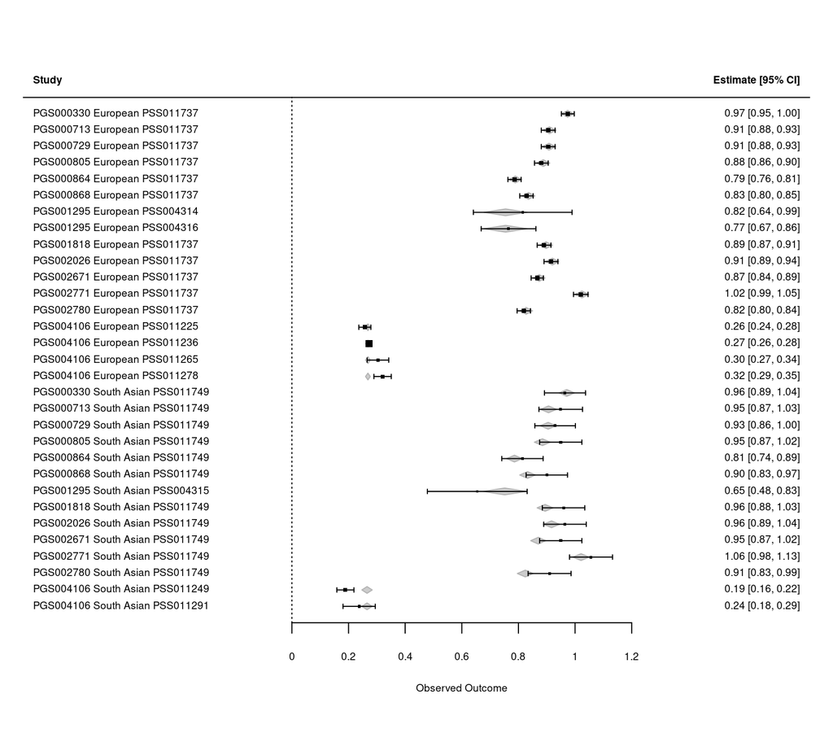

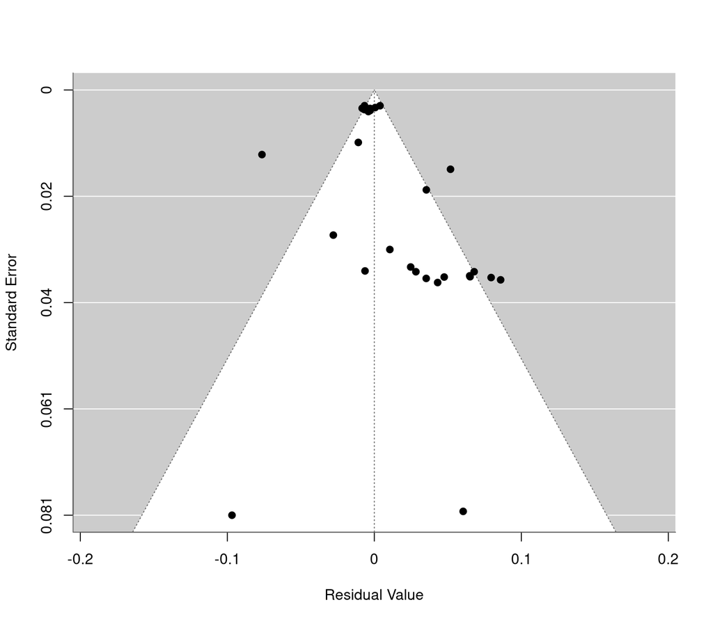

```r
diag_rma(fit_sa_4_2, sa)
```

**What we see.**

- Again the estimate is the same as the weighted `lm` (2.3), and QE / df is σ² from 2.3.

### 4.3 Add a random effect for the sample set

```r
fit_sa_4_3
```

```
Multivariate Meta-Analysis Model (k = 31; method: REML)

Variance Components:

            estim    sqrt  nlvls  fixed  factor
sigma^2    0.0016  0.0406     11     no  cohort

Test for Residual Heterogeneity:
QE(df = 17) = 68.5277, p-val < .0001

Test of Moderators (coefficients 2:14):
QM(df = 13) = 718.0188, p-val < .0001

Model Results:

                     estimate      se      zval    pval    ci.lb    ci.ub
intrcpt                1.0150  0.0346   29.3350  <.0001   0.9471   1.0828  ***
ancestrySouth Asian   -0.0449  0.0313   -1.4370  0.1507  -0.1062   0.0164
PGSPGS000713          -0.0645  0.0162   -3.9860  <.0001  -0.0962  -0.0328  ***
PGSPGS000729          -0.0666  0.0161   -4.1301  <.0001  -0.0982  -0.0350  ***
PGSPGS000805          -0.0865  0.0161   -5.3783  <.0001  -0.1180  -0.0550  ***
PGSPGS000864          -0.1850  0.0158  -11.7243  <.0001  -0.2159  -0.1541  ***
PGSPGS000868          -0.1387  0.0159   -8.7229  <.0001  -0.1698  -0.1075  ***
PGSPGS001295          -0.2532  0.0569   -4.4460  <.0001  -0.3648  -0.1416  ***
PGSPGS001818          -0.0768  0.0161   -4.7647  <.0001  -0.1083  -0.0452  ***
PGSPGS002026          -0.0542  0.0162   -3.3491  0.0008  -0.0860  -0.0225  ***
PGSPGS002671          -0.1002  0.0153   -6.5636  <.0001  -0.1301  -0.0703  ***
PGSPGS002771           0.0497  0.0166    2.9946  0.0027   0.0172   0.0822   **
PGSPGS002780          -0.1466  0.0159   -9.2211  <.0001  -0.1778  -0.1155  ***
PGSPGS004106          -0.7375  0.0364  -20.2735  <.0001  -0.8088  -0.6662  ***

---
Signif. codes:  0 '***' 0.001 '**' 0.01 '*' 0.05 '.' 0.1 ' ' 1
```

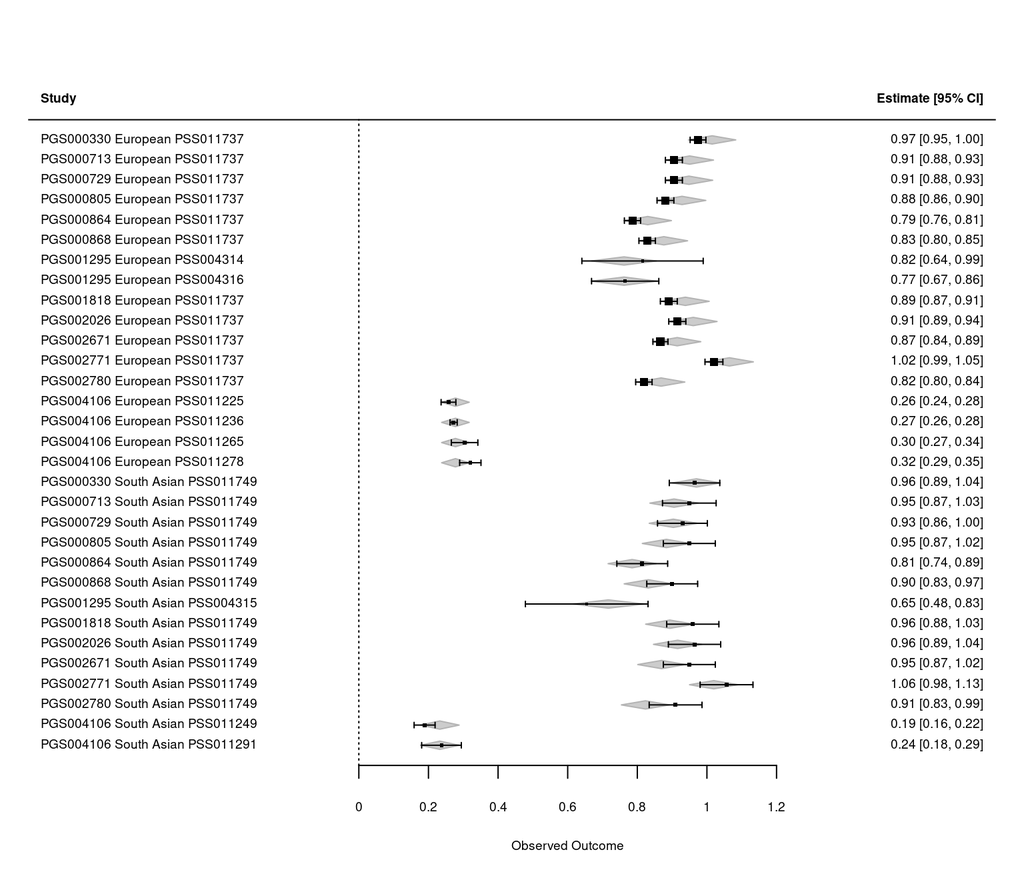

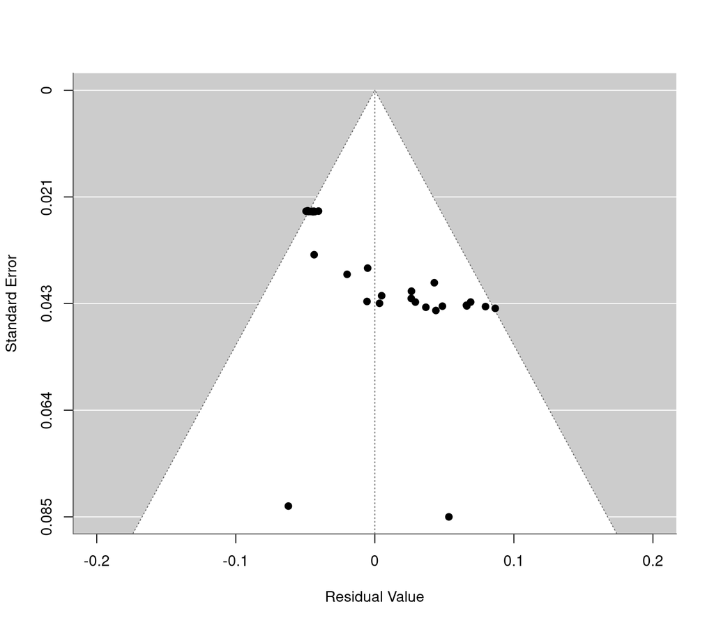

```
Profiling sigma2 = 1
```

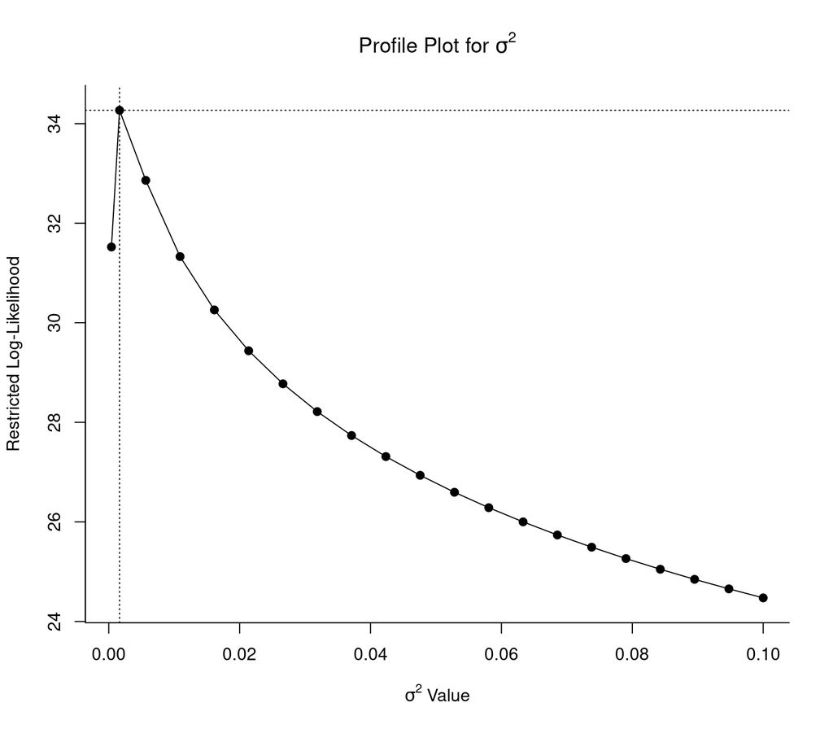

```r
diag_rma(fit_sa_4_3, sa)
```

**What we see.** As in 2.4, the estimate moves once the sample set has its own variance: Δ AUC = -0.0094.

- The last plot is new to this pipeline: the profile of the restricted log-likelihood over values of the sample-set variance σ².
- It has a clear peak near 0.0016.
- I come back to this plot in the Hispanic or Latin American comparison.

**What the metafor docs say.**

- “A profile likelihood plot should show a single peak at the corresponding ML/REML estimate” ([metafor: profile.rma](https://wviechtb.github.io/metafor/reference/profile.rma.html)). The South Asian profile has one.

### 4.4 Score and sample set as random effects

```r
fit_sa_4_4
```

```
Multivariate Meta-Analysis Model (k = 31; method: REML)

Variance Components:

            estim    sqrt  nlvls  fixed  factor
sigma^2.1  0.0356  0.1887     13     no     PGS
sigma^2.2  0.0017  0.0417     11     no  cohort

Test for Residual Heterogeneity:
QE(df = 29) = 13651.7190, p-val < .0001

Test of Moderators (coefficient 2):
QM(df = 1) = 1.6993, p-val = 0.1924

Model Results:

                     estimate      se     zval    pval    ci.lb   ci.ub
intrcpt                0.8570  0.0599  14.3153  <.0001   0.7397  0.9743  ***
ancestrySouth Asian   -0.0416  0.0319  -1.3036  0.1924  -0.1042  0.0210

---
Signif. codes:  0 '***' 0.001 '**' 0.01 '*' 0.05 '.' 0.1 ' ' 1
```

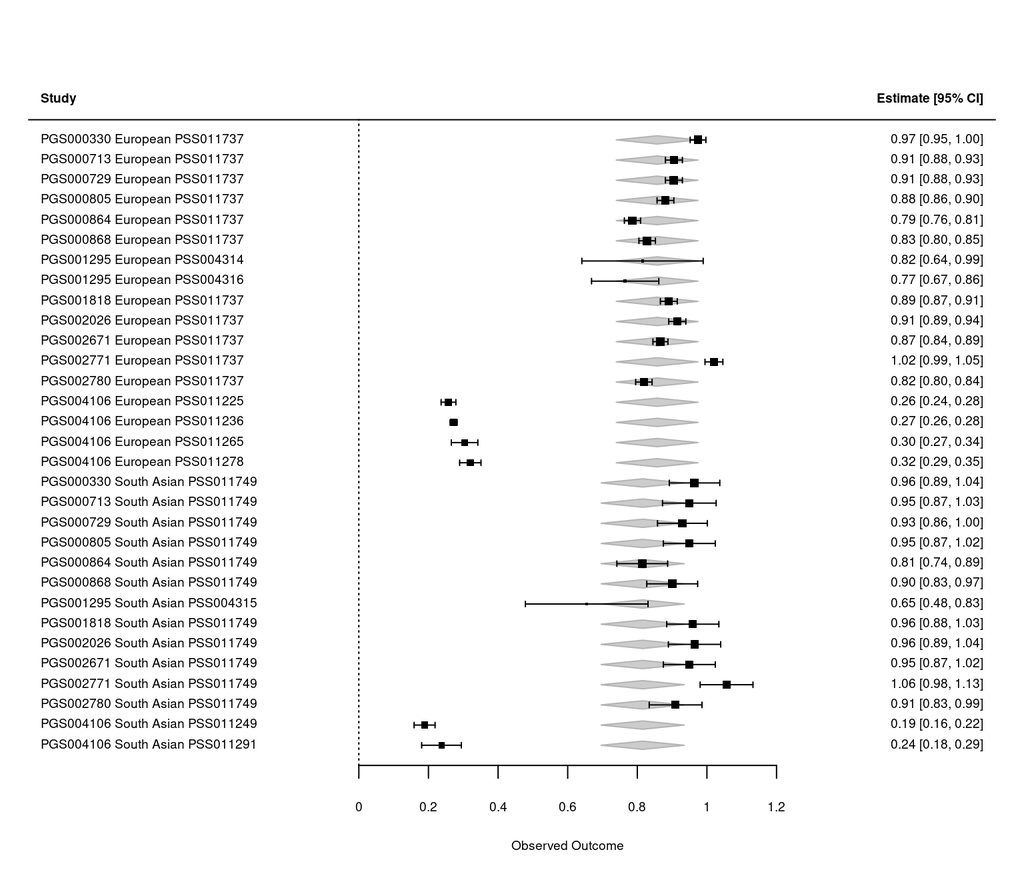

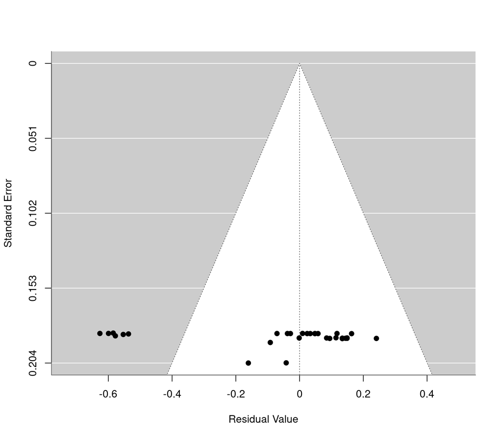

```
Profiling sigma2 = 1
```

```
Profiling sigma2 = 2
```

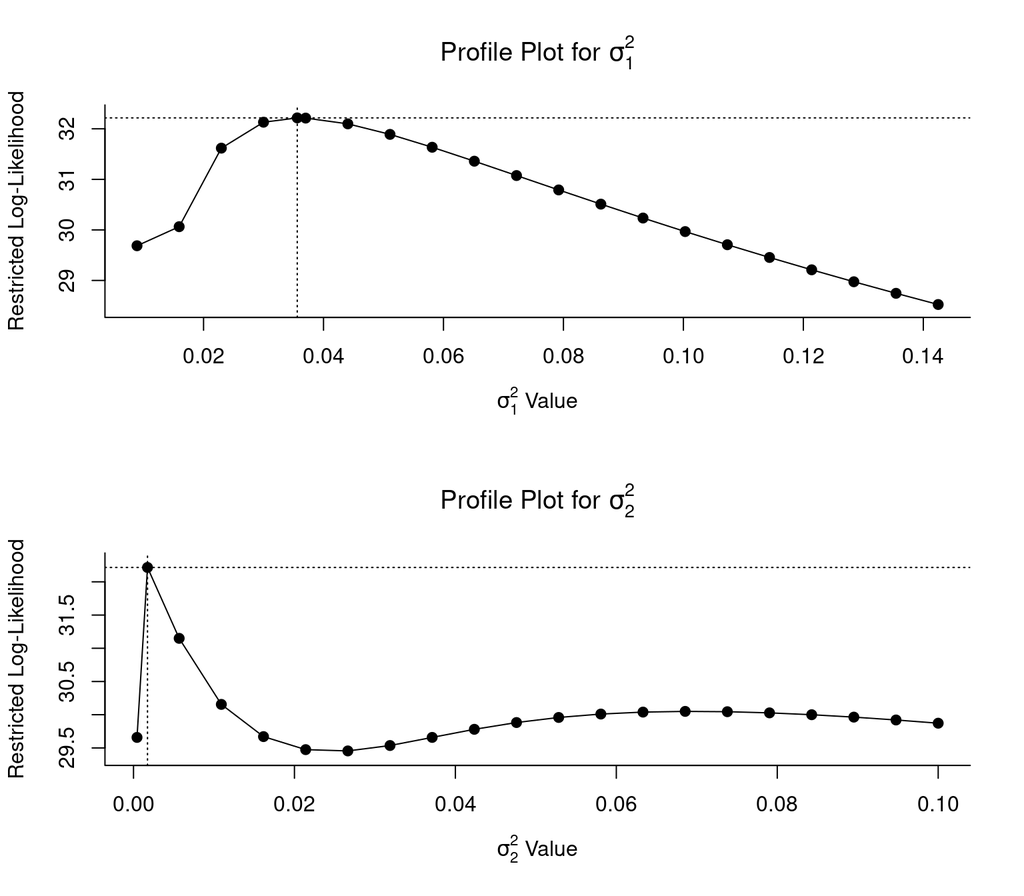

```r
diag_rma(fit_sa_4_4, sa)
```

**What we see.**

- Δ AUC = -0.0088, close to 4.3 (-0.0094).
- The profile for the sample-set variance has its highest peak at the estimate (0.0017), and a second, lower peak near 0.07.
- The metafor docs say: “If the profiled log-likelihood has multiple peaks, this indicates that the likelihood surface is not unimodal”. The estimate would be a local optimum only if the dotted lines did not meet at the highest peak, and here they do ([metafor: profile.rma](https://wviechtb.github.io/metafor/reference/profile.rma.html)).

### 4.5 A random effect for each row too

- The metafor docs say “a common mistake is to forget to add random effects at both levels”. With only the outer level, the model “assumes that the true effects for different studies within the same district are all identical” ([metafor: Konstantopoulos (2011) example](https://www.metafor-project.org/doku.php/analyses:konstantopoulos2011)). Here the district is the sample set and the studies are the rows.
- 4.3 has only the sample-set level. Following that advice, I add a random effect for each row inside its sample set: `random = ~ 1 | cohort/row`.

```r
sa$row <- factor(seq_len(nrow(sa)))
fit_sa_4_5 <- rma.mv(logit_auc, se_logit^2, mods = ~ ancestry + PGS, random = ~ 1 | cohort/row, data = sa)
record("South Asian", "4", "4.5 rma.mv(logit ~ ancestry + PGS, random = 1|cohort/row)", "logit", fit_sa_4_5, sa)
fit_sa_4_5
```

```
Multivariate Meta-Analysis Model (k = 31; method: REML)

Variance Components:

            estim    sqrt  nlvls  fixed      factor
sigma^2.1  0.0016  0.0406     11     no      cohort
sigma^2.2  0.0000  0.0000     31     no  cohort/row

Test for Residual Heterogeneity:
QE(df = 17) = 68.5277, p-val < .0001

Test of Moderators (coefficients 2:14):
QM(df = 13) = 718.0188, p-val < .0001

Model Results:

                     estimate      se      zval    pval    ci.lb    ci.ub
intrcpt                1.0150  0.0346   29.3350  <.0001   0.9471   1.0828  ***
ancestrySouth Asian   -0.0449  0.0313   -1.4370  0.1507  -0.1062   0.0164
PGSPGS000713          -0.0645  0.0162   -3.9860  <.0001  -0.0962  -0.0328  ***
PGSPGS000729          -0.0666  0.0161   -4.1301  <.0001  -0.0982  -0.0350  ***
PGSPGS000805          -0.0865  0.0161   -5.3783  <.0001  -0.1180  -0.0550  ***
PGSPGS000864          -0.1850  0.0158  -11.7243  <.0001  -0.2159  -0.1541  ***
PGSPGS000868          -0.1387  0.0159   -8.7229  <.0001  -0.1698  -0.1075  ***
PGSPGS001295          -0.2532  0.0569   -4.4460  <.0001  -0.3648  -0.1416  ***
PGSPGS001818          -0.0768  0.0161   -4.7647  <.0001  -0.1083  -0.0452  ***
PGSPGS002026          -0.0542  0.0162   -3.3491  0.0008  -0.0860  -0.0225  ***
PGSPGS002671          -0.1002  0.0153   -6.5636  <.0001  -0.1301  -0.0703  ***
PGSPGS002771           0.0497  0.0166    2.9946  0.0027   0.0172   0.0822   **
PGSPGS002780          -0.1466  0.0159   -9.2211  <.0001  -0.1778  -0.1155  ***
PGSPGS004106          -0.7375  0.0364  -20.2735  <.0001  -0.8088  -0.6662  ***

---
Signif. codes:  0 '***' 0.001 '**' 0.01 '*' 0.05 '.' 0.1 ' ' 1
```

```r
profile(fit_sa_4_5)
```

```
Profiling sigma2 = 1
```

```
Profiling sigma2 = 2
```

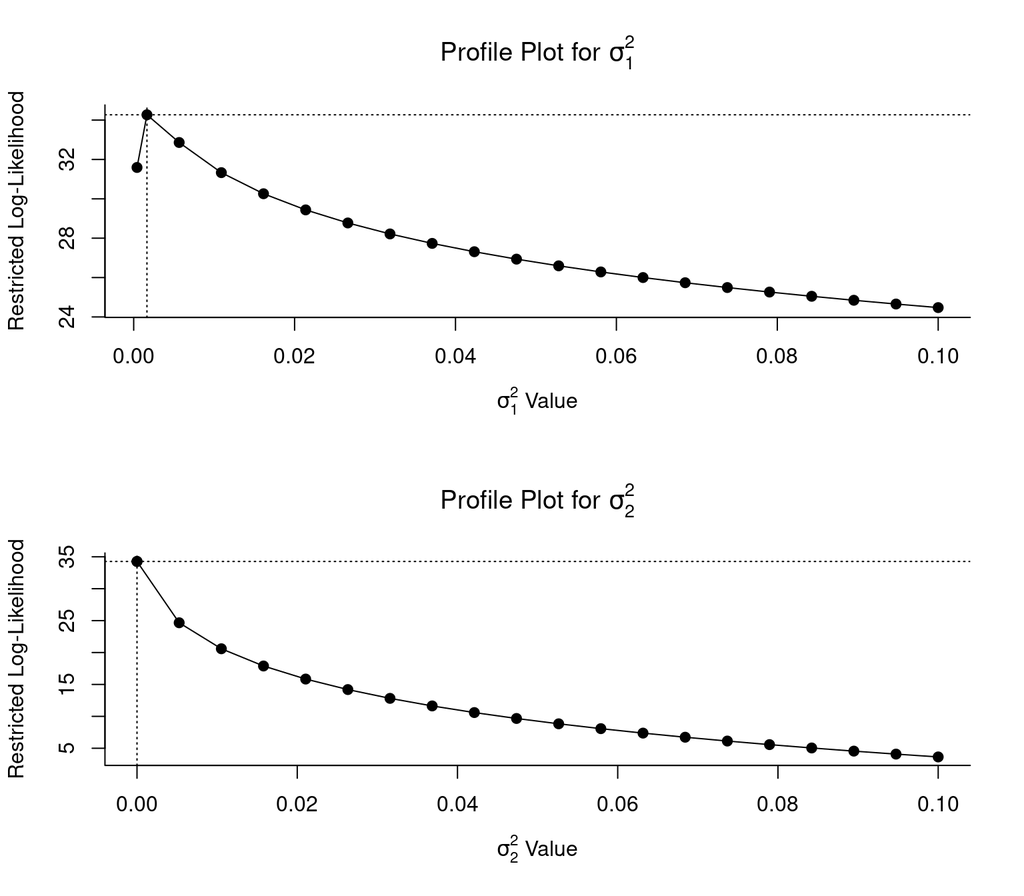

**What we see.**

- The row-level variance is estimated at 0.0000.
- Δ AUC = -0.0094, the same as in 4.3 (-0.0094).

### 4.6 Rows that share participants

- The metafor docs say standard models “assume that the effect size estimates (or more precisely, their sampling errors) are independent” ([metafor: vcalc](https://wviechtb.github.io/metafor/reference/vcalc.html)). Rows from the same study can share people, so that assumption may not hold here.
- The recommended workflow is to build the variance-covariance matrix V with `vcalc()`, fit `rma.mv()` with it, and then use `robust()` with clubSandwich, “since V is often only a rough approximation” ([metafor: recommended practices](https://wviechtb.github.io/metafor/reference/misc-recs.html)).
- I don’t know the correlation between the sampling errors of rows from the same source study, so I assume ρ = 0.6, an intermediate value between 0 (independent) and 1. In `09_review_sensitivity.R` I also try 0, 0.3 and 0.9. I would value advice on what value is reasonable here.
- With `cluster = study`, ρ also applies between European and South Asian rows of the same study (here UK Biobank), and those rows cannot share people. `vcalc()` has a `subgroup` argument for “(independent) subgroups within clusters”, which I do not use here (open question 3).
- `robust()` then clusters on the study. I only take the robust interval as usable when it has at least 4 degrees of freedom. That threshold is also my choice, and I am open to advice on it.
- The same page warns that with few clusters the degrees of freedom can be very low.

```r
V_sa <- vcalc(se_logit^2, cluster = study, obs = row, rho = 0.6, data = sa)
fit_sa_4_6 <- rma.mv(logit_auc, V_sa, mods = ~ ancestry + PGS, random = ~ 1 | cohort/row, data = sa)
record("South Asian", "4", "4.6 rma.mv(logit ~ ancestry + PGS, random = 1|cohort/row), V with rho = 0.6 within study", "logit", fit_sa_4_6, sa)
fit_sa_4_6
```

```
Multivariate Meta-Analysis Model (k = 31; method: REML)

Variance Components:

            estim    sqrt  nlvls  fixed      factor
sigma^2.1  0.0011  0.0327     11     no      cohort
sigma^2.2  0.0001  0.0102     31     no  cohort/row

Test for Residual Heterogeneity:
QE(df = 17) = 43.1911, p-val = 0.0005

Test of Moderators (coefficients 2:14):
QM(df = 13) = 814.7833, p-val < .0001

Model Results:

                     estimate      se      zval    pval    ci.lb    ci.ub
intrcpt                1.0035  0.0297   33.7706  <.0001   0.9453   1.0617  ***
ancestrySouth Asian   -0.0630  0.0282   -2.2370  0.0253  -0.1183  -0.0078    *
PGSPGS000713          -0.0589  0.0162   -3.6461  0.0003  -0.0906  -0.0273  ***
PGSPGS000729          -0.0626  0.0161   -3.8980  <.0001  -0.0941  -0.0311  ***
PGSPGS000805          -0.0784  0.0161   -4.8685  <.0001  -0.1099  -0.0468  ***
PGSPGS000864          -0.1809  0.0160  -11.3291  <.0001  -0.2122  -0.1496  ***
PGSPGS000868          -0.1301  0.0160   -8.1248  <.0001  -0.1614  -0.0987  ***
PGSPGS001295          -0.2979  0.0547   -5.4496  <.0001  -0.4050  -0.1907  ***
PGSPGS001818          -0.0687  0.0161   -4.2615  <.0001  -0.1002  -0.0371  ***
PGSPGS002026          -0.0480  0.0161   -2.9749  0.0029  -0.0797  -0.0164   **
PGSPGS002671          -0.0907  0.0158   -5.7249  <.0001  -0.1217  -0.0596  ***
PGSPGS002771           0.0547  0.0163    3.3547  0.0008   0.0227   0.0866  ***
PGSPGS002780          -0.1364  0.0161   -8.4993  <.0001  -0.1679  -0.1050  ***
PGSPGS004106          -0.7259  0.0310  -23.4085  <.0001  -0.7867  -0.6651  ***

---
Signif. codes:  0 '***' 0.001 '**' 0.01 '*' 0.05 '.' 0.1 ' ' 1
```

```r
rob_sa_4_6 <- tryCatch(
  robust(fit_sa_4_6, cluster = sa$study, clubSandwich = TRUE),
  error = function(e) { cat("robust() could not be fitted:", conditionMessage(e), "\n"); NULL }
)
```

```
Warning: Could not obtain the cluster-robust omnibus Wald test (use verbose=TRUE for more details).
```

```r
rob_sa_df <- if (is.null(rob_sa_4_6)) NA_real_ else unname(rob_sa_4_6$ddf[2])
if (!is.null(rob_sa_4_6)) print(rob_sa_4_6)
```

```
Multivariate Meta-Analysis Model (k = 31; method: REML)

Variance Components:

            estim    sqrt  nlvls  fixed      factor
sigma^2.1  0.0011  0.0327     11     no      cohort
sigma^2.2  0.0001  0.0102     31     no  cohort/row

Test for Residual Heterogeneity:
QE(df = 17) = 43.1911, p-val = 0.0005

Number of estimates:   31
Number of clusters:    6
Estimates per cluster: 1-16 (mean: 5.17, median: 1)

Model Results:

                     estimate      se¹      tval¹    df¹    pval¹    ci.lb¹    ci.ub¹
intrcpt                1.0035  0.0338    29.6800   1.15   0.0134    0.6860    1.3210    *
ancestrySouth Asian   -0.0630  0.0274    -2.3010   1.49   0.1895   -0.2291    0.1030
PGSPGS000713          -0.0589  0.0211    -2.7918      1   0.2189   -0.3271    0.2092
PGSPGS000729          -0.0626  0.0136    -4.6176      1   0.1357   -0.2348    0.1096
PGSPGS000805          -0.0784  0.0309    -2.5358      1   0.2391   -0.4709    0.3142
PGSPGS000864          -0.1809  0.0150   -12.0589      1   0.0527   -0.3715    0.0097    .
PGSPGS000868          -0.1301  0.0324    -4.0114      1   0.1555   -0.5421    0.2819
PGSPGS001295          -0.2979  0.0253   -11.7820   1.49   0.0187   -0.4507   -0.1450    *
PGSPGS001818          -0.0687  0.0310    -2.2167      1   0.2698   -0.4621    0.3248
PGSPGS002026          -0.0480  0.0233    -2.0595      1   0.2878   -0.3443    0.2482
PGSPGS002671          -0.0907  0.0362    -2.5022      1   0.2420   -0.5509    0.3696
PGSPGS002771           0.0547  0.0180     3.0389      1   0.2024   -0.1739    0.2832
PGSPGS002780          -0.1364  0.0394    -3.4592      1   0.1791   -0.6374    0.3646
PGSPGS004106          -0.7259  0.0289   -25.0749   1.37   0.0086   -0.9247   -0.5271   **

---
Signif. codes:  0 '***' 0.001 '**' 0.01 '*' 0.05 '.' 0.1 ' ' 1

1) results based on cluster-robust inference (var-cov estimator: CR2,
   approx t/F-tests and confidence intervals, df: Satterthwaite approx)
```

```r
# The robust interval is used only with at least 4 degrees of freedom (my threshold, open to advice).
if (isTRUE(rob_sa_df >= 4)) record("South Asian", "4", "4.6 robust(), clustered on study", "logit", rob_sa_4_6, sa)
c(studies = n_distinct(sa$study), robust_df_ancestry = rob_sa_df)
```

```
           studies robust_df_ancestry
            6.0000             1.4921
```

The profile plots for the two variance components of this model, as for 4.3 to 4.5:

```r
profile(fit_sa_4_6)
```

```
Profiling sigma2 = 1
```

```
Profiling sigma2 = 2
```

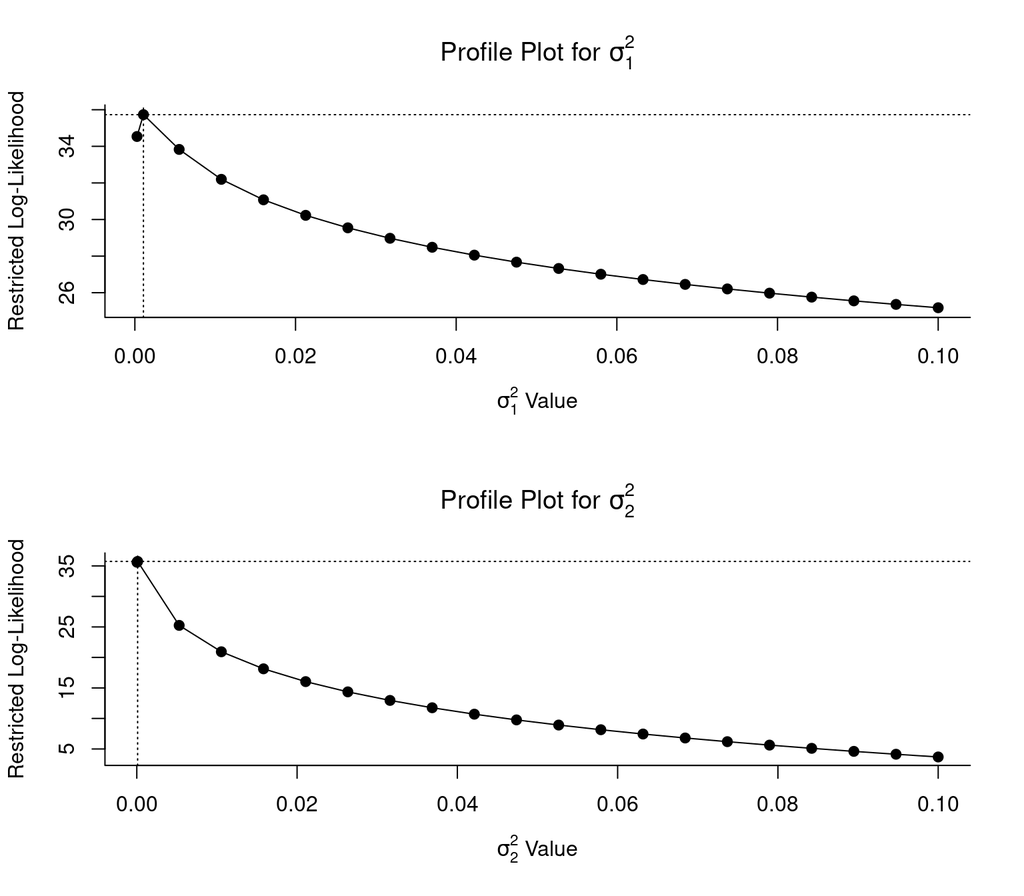

**What we see.**

- With V, Δ AUC = -0.0132 (SE 0.0060), against -0.0094 in 4.5.
- The 95% interval is -0.0249 to -0.0016.
- `robust()` uses the 6 studies as clusters. The degrees of freedom for the ancestry coefficient are 1.49, below the threshold of 4, so I don’t use the robust interval.
- On the logit scale, the robust interval for the ancestry coefficient is -0.2291 to 0.1030. The model-based interval from the same fit is -0.1183 to -0.0078.
- The same model with other values of ρ:

```r
sa_rho <- map_dfr(c(0, 0.3, 0.6, 0.9), function(r) {
  V <- vcalc(se_logit^2, cluster = study, obs = row, rho = r, data = sa)
  f <- rma.mv(logit_auc, V, mods = ~ ancestry + PGS, random = ~ 1 | cohort/row, data = sa)
  a <- to_auc(f, sa)
  tibble(rho = r, delta_auc = a[["est"]], se_auc = a[["se"]], lo = a[["est"]] - 1.96 * a[["se"]], hi = a[["est"]] + 1.96 * a[["se"]])
})
sa_rho_excl <- sa_rho$rho[sa_rho$lo > 0 | sa_rho$hi < 0]
kable(sa_rho %>% transmute(rho, `Δ AUC` = delta_auc, `SE (AUC)` = se_auc, `95% CI` = paste0(fmt(lo), " to ", fmt(hi))), digits = 4)
```

| rho | Δ AUC | SE (AUC) | 95% CI |
| --- | --- | --- | --- |
| 0.0 | -0.0094 | 0.0065 | -0.0222 to 0.0034 |
| 0.3 | -0.0113 | 0.0062 | -0.0234 to 0.0008 |
| 0.6 | -0.0132 | 0.0060 | -0.0249 to -0.0016 |
| 0.9 | -0.0157 | 0.0062 | -0.0279 to -0.0035 |

- The interval excludes 0 for ρ = 0.6, 0.9.

### Pipeline 4 so far

```r
sa_models_p4 <- est_tbl %>% filter(comparison == "South Asian", pipeline %in% c("1", "2", "4")) %>% pull(model)
show_rows("South Asian", sa_models_p4)
```

| model | scale | estimate (model scale) | SE (model scale) | σ | Δ AUC | SE (AUC) | 95% CI | note |
| --- | --- | --- | --- | --- | --- | --- | --- | --- |
| 1. IVW stage 1 → stage 2 | AUC | 0.00072 | 0.00199 | NA | 0.00072 | 0.00199 | -0.0032 to 0.0046 |  |
| 2.1 lm(logit ~ ancestry), weighted | logit | -0.00379 | 0.19845 | 21.69675 | -0.00086 | 0.04495 | -0.0890 to 0.0872 |  |
| 2.2 lm(logit ~ ancestry + PGS) | logit | 0.01165 | 0.01819 | 0.04980 | 0.00243 | 0.00379 | -0.0050 to 0.0099 |  |
| 2.3 lm(logit ~ ancestry + PGS), weighted | logit | -0.00309 | 0.01837 | 2.00774 | -0.00065 | 0.00386 | -0.0082 to 0.0069 |  |
| 2.4 lmer(logit ~ ancestry + PGS + (1\|cohort)), weighted | logit | -0.04927 | 0.02997 | 0.73633 | -0.01027 | 0.00625 | -0.0225 to 0.0020 |  |
| 2.5 lmer(logit ~ ancestry + (1\|PGS) + (1\|cohort)), weighted | logit | -0.04632 | 0.03063 | 0.73759 | -0.00977 | 0.00647 | -0.0224 to 0.0029 |  |
| 4.1 rma.mv(logit ~ ancestry) | logit | -0.00379 | 0.00915 | NA | -0.00086 | 0.00207 | -0.0049 to 0.0032 |  |
| 4.2 rma.mv(logit ~ ancestry + PGS) | logit | -0.00309 | 0.00915 | NA | -0.00065 | 0.00192 | -0.0044 to 0.0031 |  |
| 4.3 rma.mv(logit ~ ancestry + PGS, random = 1\|cohort) | logit | -0.04493 | 0.03127 | NA | -0.00937 | 0.00653 | -0.0222 to 0.0034 |  |
| 4.4 rma.mv(logit ~ ancestry, random = 1\|PGS + 1\|cohort) | logit | -0.04161 | 0.03192 | NA | -0.00878 | 0.00674 | -0.0220 to 0.0044 |  |
| 4.5 rma.mv(logit ~ ancestry + PGS, random = 1\|cohort/row) | logit | -0.04493 | 0.03127 | NA | -0.00937 | 0.00653 | -0.0222 to 0.0034 |  |
| 4.6 rma.mv(logit ~ ancestry + PGS, random = 1\|cohort/row), V with rho = 0.6 within study | logit | -0.06303 | 0.02818 | NA | -0.01324 | 0.00595 | -0.0249 to -0.0016 |  |

## Pipeline 5: AUC scale, `rma.mv`

I fit the same four models with AUC as the outcome and SE(AUC)² as the known variances.

```r
fit_sa_5_1 <- rma.mv(auc, se_auc^2, mods = ~ ancestry, data = sa)
fit_sa_5_2 <- rma.mv(auc, se_auc^2, mods = ~ ancestry + PGS, data = sa)
fit_sa_5_3 <- rma.mv(auc, se_auc^2, mods = ~ ancestry + PGS, random = ~ 1 | cohort, data = sa)
fit_sa_5_4 <- rma.mv(auc, se_auc^2, mods = ~ ancestry, random = list(~ 1 | PGS, ~ 1 | cohort), data = sa)
```

### 5.1 Ancestry only

```r
fit_sa_5_1
```

```
Multivariate Meta-Analysis Model (k = 31; method: REML)

Variance Components: none

Test for Residual Heterogeneity:
QE(df = 29) = 13587.8560, p-val < .0001

Test of Moderators (coefficient 2):
QM(df = 1) = 1.4318, p-val = 0.2315

Model Results:

                     estimate      se       zval    pval    ci.lb   ci.ub
intrcpt                0.6627  0.0006  1077.4138  <.0001   0.6615  0.6639  ***
ancestrySouth Asian    0.0024  0.0020     1.1966  0.2315  -0.0015  0.0063

---
Signif. codes:  0 '***' 0.001 '**' 0.01 '*' 0.05 '.' 0.1 ' ' 1
```

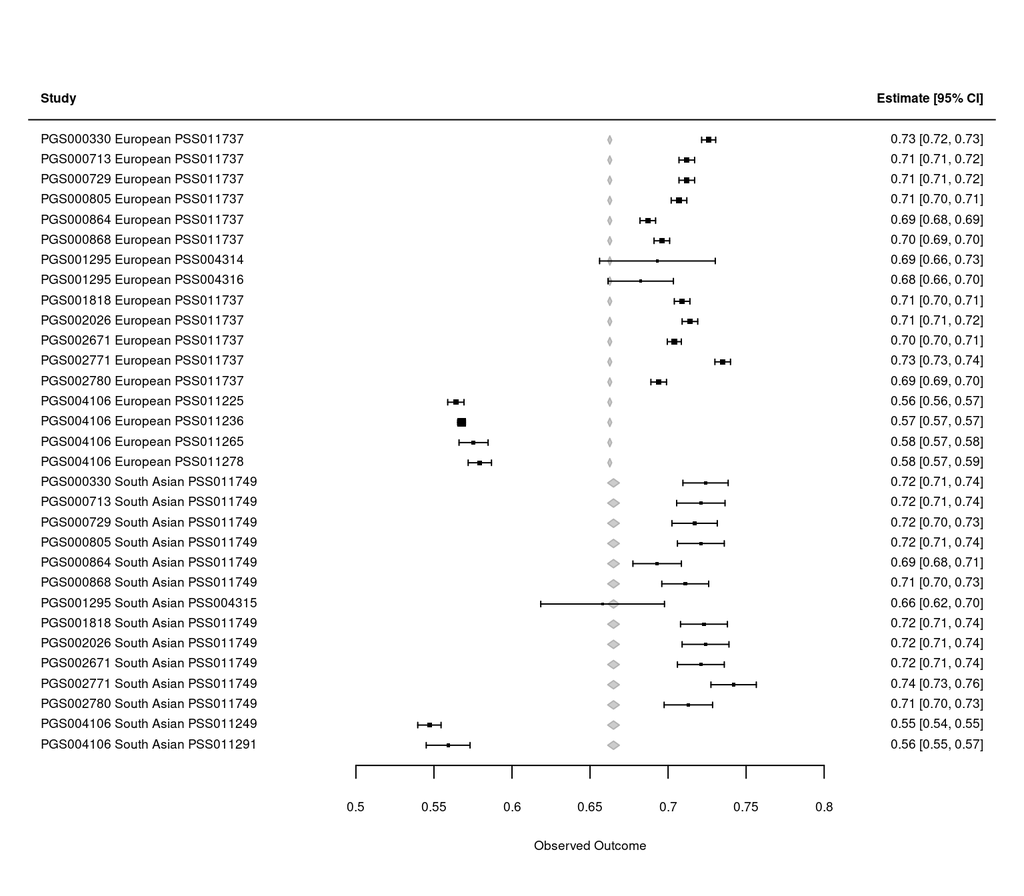

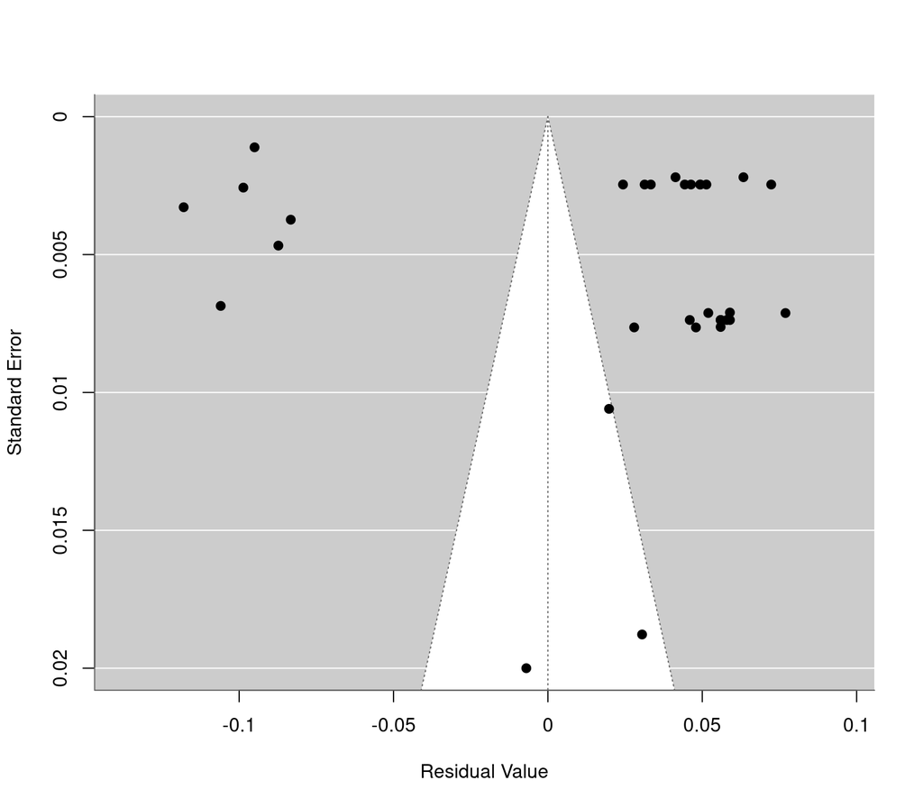

```r
diag_rma(fit_sa_5_1, sa)
```

### 5.2 Add the score

```r
fit_sa_5_2
```

```
Multivariate Meta-Analysis Model (k = 31; method: REML)

Variance Components: none

Test for Residual Heterogeneity:
QE(df = 17) = 68.9410, p-val < .0001

Test of Moderators (coefficients 2:14):
QM(df = 13) = 13520.3468, p-val < .0001

Model Results:

                     estimate      se      zval    pval    ci.lb    ci.ub
intrcpt                0.7258  0.0022  330.2663  <.0001   0.7215   0.7301  ***
ancestrySouth Asian    0.0007  0.0020    0.3594  0.7193  -0.0032   0.0046
PGSPGS000713          -0.0130  0.0033   -3.9694  <.0001  -0.0194  -0.0066  ***
PGSPGS000729          -0.0133  0.0033   -4.0838  <.0001  -0.0197  -0.0069  ***
PGSPGS000805          -0.0174  0.0033   -5.3406  <.0001  -0.0238  -0.0110  ***
PGSPGS000864          -0.0383  0.0033  -11.7005  <.0001  -0.0447  -0.0319  ***
PGSPGS000868          -0.0283  0.0033   -8.6795  <.0001  -0.0347  -0.0219  ***
PGSPGS001295          -0.0455  0.0087   -5.2160  <.0001  -0.0627  -0.0284  ***
PGSPGS001818          -0.0154  0.0033   -4.7279  <.0001  -0.0218  -0.0090  ***
PGSPGS002026          -0.0108  0.0033   -3.3187  0.0009  -0.0172  -0.0044  ***
PGSPGS002671          -0.0204  0.0031   -6.5817  <.0001  -0.0265  -0.0143  ***
PGSPGS002771           0.0099  0.0033    3.0391  0.0024   0.0035   0.0163   **
PGSPGS002780          -0.0300  0.0033   -9.1865  <.0001  -0.0365  -0.0236  ***
PGSPGS004106          -0.1592  0.0024  -65.8432  <.0001  -0.1639  -0.1544  ***

---
Signif. codes:  0 '***' 0.001 '**' 0.01 '*' 0.05 '.' 0.1 ' ' 1
```

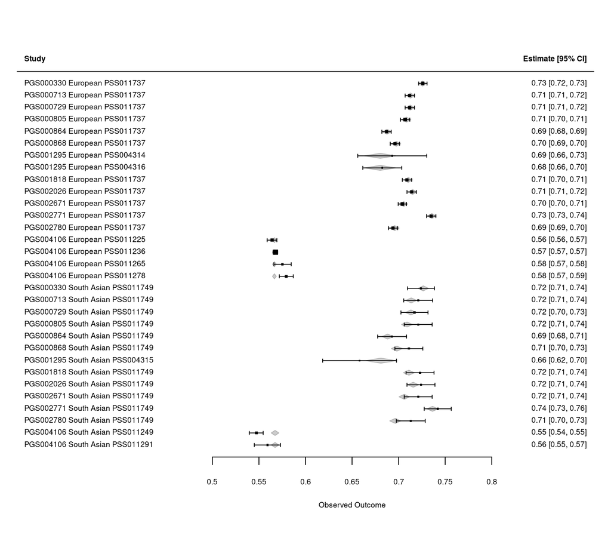

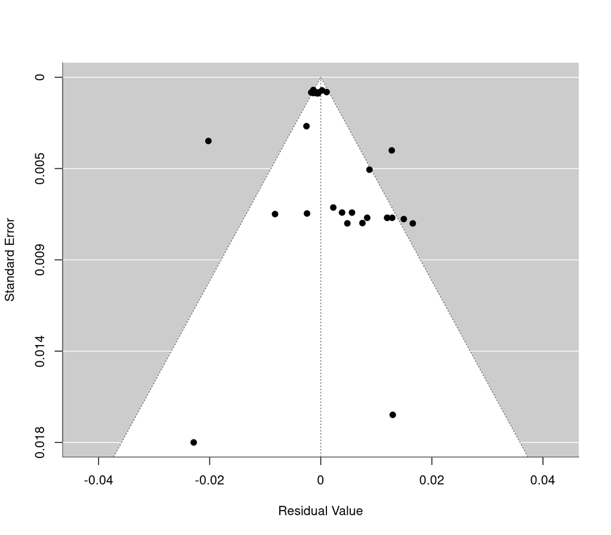

```r
diag_rma(fit_sa_5_2, sa)
```

**What we see.**

- This model gives the same estimate as the weighted `lm` in 3.3, and its SE is close to the pipeline 1 SE:

```r
c(
  delta_auc_rma = get_est("South Asian", "5.2 rma.mv(AUC ~ ancestry + PGS)"),
  delta_auc_pipeline_1 = sa_p1[["delta_auc"]],
  se_rma = get_est("South Asian", "5.2 rma.mv(AUC ~ ancestry + PGS)", "se"),
  se_pipeline_1 = sa_p1[["se"]]
)
```

```
       delta_auc_rma delta_auc_pipeline_1               se_rma        se_pipeline_1
          0.00071603           0.00071700           0.00199245           0.00199251
```